# Benchmarking deep learning models on large healthcare datasets - ScienceDirect

- [View **PDF**](https://www.sciencedirect.com/science/article/pii/S1532046418300716/pdfft?md5=2c2266a54e772aa8d5d157ec654e39cf&pid=1-s2.0-S1532046418300716-main.pdf)

## [Journal of Biomedical Informatics](https://www.sciencedirect.com/journal/journal-of-biomedical-informatics)

[Volume 83](https://www.sciencedirect.com/journal/journal-of-biomedical-informatics/vol/83/suppl/C), July 2018, Pages 112-134

# Benchmarking deep learning models on large healthcare datasets

https://doi.org/10.1016/j.jbi.2018.04.007[Get rights and content](https://s100.copyright.com/AppDispatchServlet?publisherName=ELS&contentID=S1532046418300716&orderBeanReset=true)

Under an Elsevier [user license](http://www.elsevier.com/open-access/userlicense/1.0/)

open archive

## Highlights

- •

  Exhaustive benchmarking evaluation of [deep learning models](https://www.sciencedirect.com/topics/computer-science/deep-learning-model) on MIMIC-III dataset.
- •

  Mortality, Length of stay, and ICD-9 code prediction tasks are used for evaluation.
- •

  Deep learning models achieve the best performance compared to all existing models.
- •

  Deep learning models perform well with raw clinical time series features.

## Abstract

Deep learning models (aka Deep Neural Networks) have revolutionized many fields including computer vision, natural language processing, speech recognition, and is being increasingly used in clinical healthcare applications. However, few works exist which have benchmarked the performance of the deep learning models with respect to the state-of-the-art machine learning models and prognostic scoring systems on publicly available healthcare datasets. In this paper, we present the benchmarking results for several clinical prediction tasks such as mortality prediction, length of stay prediction, and ICD-9 code group prediction using Deep Learning models, ensemble of machine learning models (Super Learner algorithm), SAPS II and SOFA scores. We used the Medical Information Mart for Intensive Care III (MIMIC-III) (v1.4) publicly available dataset, which includes all patients admitted to an ICU at the Beth Israel Deaconess Medical Center from 2001 to 2012, for the benchmarking tasks. Our results show that deep learning models consistently outperform all the other approaches especially when the ‘raw’ clinical time series data is used as input features to the models.

## Graphical abstract

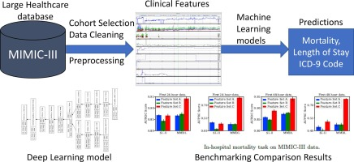

## Keywords

Deep learning models

Super learner algorithm

Mortality prediction

Length of stay

ICD-9 code group prediction

## 1. Introduction

Quantifying patient health and predicting future outcomes is an important problem in critical care research. Patient mortality and length of hospital stay are the most important clinical outcomes for an [ICU](https://www.sciencedirect.com/topics/medicine-and-dentistry/intensive-care-unit) admission, and accurately predicting them can help with the assessment of severity of illness; and determining the value of novel [treatments](https://www.sciencedirect.com/topics/medicine-and-dentistry/therapeutic-procedure), interventions and [health care](https://www.sciencedirect.com/topics/medicine-and-dentistry/health-care) policies. With the goal of accurately predicting these clinical outcomes, researchers have developed novel [machine learning](https://www.sciencedirect.com/topics/computer-science/machine-learning) models [1], [2] and scoring systems [3] while measuring the improvement using performance measures such as sensitivity, specificity and Area under the ROC (AUROC). The availability of large healthcare databases such as Medical [Information Mart](https://www.sciencedirect.com/topics/computer-science/information-mart) for Intensive Care (MIMIC-II and III) databases [4], [5] has accelerated the research in this important area as evidenced by a lot of recent publications [6], [7], [8], [2], [9], [10], [11], [1], [12], [13], [14], [15], [16], [17], [18], [19], [20], [21], [22].

Severity scores such as SAPS-II [3], SOFA [23], and APACHE [24] have been developed with the objective of predicting hospital mortality from baseline [patient characteristics](https://www.sciencedirect.com/topics/medicine-and-dentistry/patient-characteristics), defined as the measurements obtained within the first 24 h after ICU admission. Most of these scoring systems choose a small number of hand-picked explanatory predictors and use simple models such as [logistic regression](https://www.sciencedirect.com/topics/medicine-and-dentistry/logistic-regression-analysis) to predict mortality, while making linear and additive relationship assumptions between the outcome variable (mortality) and the predictors. Earlier studies [25], [26] have shown that such assumptions are unrealistic and that [nonparametric methods](https://www.sciencedirect.com/topics/computer-science/nonparametric-method) might perform better than standard logistic regression models in predicting ICU mortality.

With the recent advances and success of machine learning and [deep learning](https://www.sciencedirect.com/topics/computer-science/deep-learning), many researchers have adopted these models for clinical prediction tasks for ICU admissions. Early works [27], [28], [29] showed that machine learning models obtain good results on mortality prediction and forecasting length of stay in ICU. Recently, Pirracchio [30] showed that a Super Learner algorithm [31]-an ensemble of machine learning models, offers improved performance for predicting hospital mortality in ICU patients and compared its performance to several severity scores on the MIMIC-II dataset. Johnson et al. [6] compared several published works against [gradient boosting](https://www.sciencedirect.com/topics/computer-science/gradient-boosting) and logistic regression models using a simple set of features extracted from MIMIC-III dataset [5] for ICU mortality prediction. Harutyunyan et al. [2] empirically validated four clinical prediction benchmarking tasks on the MIMIC-III dataset using deep models. Even though some of these recent efforts have attempted to benchmark the machine learning models on MIMIC datasets, they do not provide a consistent and exhaustive set of benchmark comparison results of deep learning models for a variety of prediction tasks on the large healthcare datasets. Thus, in this paper, we report an exhaustive set of benchmarking results of applying deep learning models for MIMIC-III dataset and compare it with state-of-the art [machine learning approaches](https://www.sciencedirect.com/topics/computer-science/machine-learning-approach) and scoring systems. Table 1 shows the comparison of benchmarking works. We summarize the main contributions of this work below:

- •

  We present detailed benchmarking results of deep learning models on MIMIC-III dataset for three clinical prediction tasks including mortality prediction, forecasting length of stay, and ICD-9 code group prediction. Our experiments show that deep learning models consistently perform better than the several existing machine learning models and severity scoring systems.
- •

  We present benchmarking results on different feature sets including ‘processed’ and ‘raw’ clinical time series. We show that deep learning models obtain better results on ‘raw’ features which indicates that rule-based preprocessing of clinical features is not necessary for deep learning models.

Table 1. Comparison of benchmarking works.

| Empty Cell | Empty Cell | [30] | [2] | [6] | This work |
| --- | --- | --- | --- | --- | --- |
| Time durations | 24 h | ✓ |  | ✓ | ✓ |
|  | 48 h |  | ✓ | ✓ | ✓ |
| Number of features | Smaller feature set | ✓ | ✓ | ✓ | ✓ |
|  | Larger feature set |  |  |  | ✓ |
| Feature type | Non-time series | ✓ |  | ✓ | ✓ |
|  | Time-series |  | ✓ |  | ✓ |
| Databases | MIMIC-II | ✓ |  |  |  |
|  | MIMIC-III |  | ✓ | ✓ | ✓ |
|  | MIMIC-III (CareVue) |  |  |  | ✓ |
| Scoring systems | SAPS -II | ✓ |  |  | ✓ |
|  | SOFA | ✓ |  |  | ✓ |
| Prediction algorithms | Machine learning models | ✓ |  | ✓ | ✓ |
|  | Deep learning models |  | ✓ |  | ✓ |
| Prediction tasks | In-hospital mortality | ✓ | ✓ | ✓ | ✓ |
|  | Short-term mortality |  |  |  | ✓ |
|  | Long-term mortality |  |  |  | ✓ |
|  | Length of stay |  | ✓ |  | ✓ |
|  | Phenotyping |  | ✓ |  |  |
|  | ICD-9 code group |  | ✓ |  | ✓ |

The remainder of this paper is arranged as follows: in Section 2, we provide an overview of the related work; in Section 3, we describe MIMIC-III dataset and the pre-processing steps we employed to obtain the benchmark datasets; the benchmarking experiments is discussed in Section 4; and we conclude with summary in Section 5.

## 2. Related work

We first provide a brief review of [machine learning](https://www.sciencedirect.com/topics/computer-science/machine-learning) and [deep learning](https://www.sciencedirect.com/topics/computer-science/deep-learning) models for healthcare applications, and then discuss the existing works on benchmarking healthcare datasets.

Early works [32], [33] have shown that machine learning models obtain good results on mortality prediction and medical risk evaluation. Physionet challenge<sup>2</sup> - a friendly competition platform - has resulted in development of machine learning models for addressing some of the open healthcare problems. With the recent advances in [deep learning techniques](https://www.sciencedirect.com/topics/computer-science/deep-learning-technique), there is a growing interest in applying these techniques to healthcare applications due to the increasing availability of large-scale [health care](https://www.sciencedirect.com/topics/medicine-and-dentistry/health-care) data [34], [7], [35], [36]. For example, Che et al. [7] developed a scalable deep learning framework which models the prior-knowledge from medical ontologies to learn clinically relevant features for disease diagnosis. A recent study [37] showed that a [neural network model](https://www.sciencedirect.com/topics/computer-science/neural-network-model) can improve the prediction of several psychological conditions such as anxiety, behavioral disorders, depression, and post-traumatic stress disorder. Other recent works [38], [39], [40] have leveraged the power of deep learning approaches to model diseases and clinical [time series data](https://www.sciencedirect.com/topics/computer-science/time-series-data). These previous work have demonstrated the strong performance by deep learning models in health care applications, which significantly alleviates the tedious work on feature engineering and extraction.

The availability of deidentified public datasets such as Medical [Information Mart](https://www.sciencedirect.com/topics/computer-science/information-mart) for Intensive Care (MIMIC-II [4] and MIMIC-III [5]) has enabled researchers to benchmark machine learning models for studying [ICU](https://www.sciencedirect.com/topics/medicine-and-dentistry/intensive-care-unit) clinical outcomes such as mortality and length of hospital stay. Recent works such as Li-Wei et al. [41] and Lee [42] have proposed and studied machine learning models for predicting mortality of ICU patients. Pirracchio [30] used MIMIC II clinical data [4] to predict mortality in the ICU and showed that the Super Learner algorithm - an ensemble of machine learning models, performs better than [SAPS II](https://www.sciencedirect.com/topics/medicine-and-dentistry/saps-ii), APACHE II and SOFA scores. Their work showed that machine learning models outperform the prognostic scores, but they did not compare their results with the recent deep learning models. Harutyunyan et al. [2] proposed a deep learning model called multi-task [Recurrent Neural Networks](https://www.sciencedirect.com/topics/computer-science/recurrent-neural-network) to empirically validate four clinical prediction benchmarking tasks on the MIMIC-III database. While, their work showed promising benchmark results of deep learning models, they compared their proposed model only with a standard [Logistic Regression](https://www.sciencedirect.com/topics/medicine-and-dentistry/logistic-regression-analysis) model and a [Long Short Term Memory Network](https://www.sciencedirect.com/topics/computer-science/long-short-term-memory-network) [43], and omitted comparison with scoring systems (SAPS-II) or other machine learning models (such as Super Learner). Johnson et al. [6] studied the challenge of reproducing the published results on the public MIMIC-III dataset using a case-study on mortality prediction task. They reviewed 28 publications and then compared the performance reported in these studies against [gradient boosting](https://www.sciencedirect.com/topics/computer-science/gradient-boosting) and logistic regression models using a simple set of features extracted from MIMIC-III dataset. They demonstrated that the large heterogeneity in studies highlighted the need for improvements in the way that prediction tasks are reported to enable fairer comparison between models. Our work advances the efforts of these previous benchmark works by providing a consistent and exhaustive set of benchmarking results of deep learning models on several prediction tasks.

## 3. MIMIC-III dataset

In this section, we describe the MIMIC-III dataset and discuss the steps we employed to preprocess and extract the features for our benchmarking experiments.

### 3.1. Dataset description

MIMIC III [5] is a publicly available critical care database maintained by the Massachusetts Institute of Technology (MIT)’s Laboratory for Computational Physiology. This database integrates deidentified, comprehensive clinical data of patients admitted to an Intensive Care Unit (ICU) at the Beth Israel Deaconess Medical Center (BIDMC) in Boston, Massachusetts during 2001 to 2012.

MIMIC-III contains data associated with 53,423 distinct hospital admissions for adult patients (aged 15 years or above) and 7870 neonates admitted to an ICU at the BIDMC. The data covers 38,597 distinct adult patients with 49,785 hospital admissions. To obtain consistent [benchmarking datasets](https://www.sciencedirect.com/topics/computer-science/benchmarking-dataset), in this paper we only include the first ICU admission of the patients. Table 2 shows the statistics of our dataset, and Table 3 shows the baseline characteristics and outcome measures of our dataset. We observe that the median age of adult patients is 65.86 years (Quartile Q1–Q3: 52.72–77.97) with 56.76% patients are male, in-hospital mortality around 10.49% and the median length of an hospital stay is 7.08 days (Q1–Q3: 4.32–12.03).

Table 2. Summary statistics of MIMIC-III dataset.

| Data | Total |
| --- | --- |
| # admissions in the MIMIC-III (v1.4) database | 58,576 |
| # admissions which are the first admission of the patient | 46,283 |
| # admissions which are the first admission of an adult patient (>15 years old) | 38,425 |
| # admissions where adult patient died 24 h after the first admission | 35,627 |

Table 3. Baseline characteristics and in-hospital mortality outcome measures. Continuous variables are presented as *Median [InterQuartile Range Q1–Q3]*; binary or [categorical variables](https://www.sciencedirect.com/topics/computer-science/categorical-variable) as *Count (%)*.

| Empty Cell | Overall | Dead at hospital | Alive at hospital |
| --- | --- | --- | --- |
| *General* |  |  |  |
| # admissions | 35,627 | 3738 | 31,889 |
| Age | 65.86 [52.72–77.97] | 73.85 [60.16–82.85] | 64.98 [52.04–77.21] |
| Gender (female) | 15,409 (43.24%) | 1731 (46.31%) | 13,678 (42.88%) |
| First SAPS-II | 33.00 [25.00–42.00] | 48.00 [38.00–59.00] | 32.00 [24.00–40.00] |
| First SOFA | 3.00 [2.00–6.00] | 6.00 [4.00–9.00] | 3.00 [2.00–5.00] |
| *Origin* |  |  |  |
| Medical | 24,720 (69.37%) | 2969 (79.43%) | 21,751 (68.19%) |
| Emergency surgery | 6134 (17.21%) | 663 (17.74%) | 5471 (17.15%) |
| Scheduled surgery | 4783 (13.42%) | 106 (2.84%) | 4677 (14.66%) |
| *Site* |  |  |  |
| MICU | 12,621 (35.42%) | 1814 (48.53%) | 10,807 (33.88%) |
| MSICU | 5821 (16.33%) | 691 (18.49%) | 5130 (16.08%) |
| CCU | 5180 (14.54%) | 523 (13.99%) | 4657 (14.60%) |
| CSRU | 7264 (20.38%) | 245 (6.55%) | 7019 (22.00%) |
| TSICU | 4751 (13.33%) | 465 (12.44%) | 4286 (13.44%) |
| *Lab results* |  |  |  |
| HR (bpm) | 84.00 [73.00–97.00] | 90.00 [75.00–107.00] | 84.00 [72.00–96.00] |
| MAP (mmhg) | 76.00 [67.33–87.00] | 74.00 [64.67–86.00] | 77.00 [68.00–87.00] |
| RR (cpm) | 18.00 [14.00–22.00] | 20.00 [16.00–24.00] | 18.00 [14.00–21.00] |
| Na (mmol/l) | 138.00 [136.00–141.00] | 139.00 [135.00–142.00] | 138.00 [136.00–141.00] |
| K (mmol/l) | 4.10 [3.80–4.60] | 4.20 [3.70–4.70] | 4.10 [3.80–4.60] |
| $HCO3$ (mmol/l) | 24.00 [21.00–26.00] | 22.00 [18.00–25.00] | 24.00 [21.00–26.00] |
| WBC (10<sup>3</sup>/mm<sup>3</sup>) | 11.00 [7.90–14.90] | 12.30 [8.00–17.20] | 10.80 [7.90–14.60] |
| P/F ratio | 257.50 [180.00–352.50] | 218.66 [140.00–331.86] | 262.50 [187.00–355.00] |
| Ht (%) | 31.00 [26.00–36.00] | 31.00 [27.00–36.00] | 31.00 [26.00–36.00] |
| Urea (mmol/l) | 1577.00 [968.00–2415.00] | 1020.00 [518.50–1780.00] | 1640.00 [1035.00–2470.00] |
| Bilirubine (mg/dl) | 0.70 [0.40–1.70] | 1.00 [0.50–3.50] | 0.70 [0.40–1.50] |
| *Outcomes* |  |  |  |
| Hospital LOS (days) | 7.08 [4.32–12.03] | 7.21 [3.31–14.44] | 7.07 [4.40–11.88] |
| ICU death (%) | 2860 (8.03%) | 2860 (76.51%) | – |
| Hospital death (%) | 3738 (10.49%) | 3738 (100%) | – |

### 3.2. Dataset preprocessing

In this section, we describe in detail the cohort selection, data extraction, data cleaning and feature extraction methods we employed to preprocess our MIMIC-III dataset.

#### 3.2.1. Cohort selection

The first step of dataset preprocessing includes cohort selection. We used two sets of [inclusion criterion](https://www.sciencedirect.com/topics/computer-science/inclusion-criterion) to select the patients to prepare the benchmark datasets. First, we identified all the adult patients by using the age recorded at the time of ICU admission. Following previous studies [6], in our work, all the patients whose age was >15 years at the time of ICU admission is considered as an adult.<sup>3</sup> Second, for each patient, we only use their first admission in our benchmark datasets and for subsequent analysis, and dropped all their later admissions. This was done to prevent possible [information leakage](https://www.sciencedirect.com/topics/computer-science/information-leakage) in the analysis, and to ensure similar experimental settings compared to the related works [6].

#### 3.2.2. Data extraction

There are 26 tables in the MIMIC-III (v1.4) [relational database](https://www.sciencedirect.com/topics/computer-science/relational-database). Charted events such as laboratory tests, doctor notes and fluids into/out of patients are stored in a series of ’events’ tables. For the purpose of preparing benchmark datasets to predict clinical tasks, we extracted data for the selected cohort from the following tables: *inputevents (inputevents*_*cv/inputevents*_*mv)* (intake for patients monitored using Philips CareVue system/iMDSoft MetaVision system), *outputevents* (output information for patients while in the ICU), *chartevents* (all charted observations for patients), *labevents* (laboratory measurements for patients both within the hospital and in outpatient clinics), and *prescriptions* (medications ordered, and not necessarily administered, for a given patient). We selected these tables as they provide the most relevant clinical features for the prediction tasks considered in this work. We obtained the following two benchmark datasets:

- •

  MIMIC-III: This includes the data extracted from all the above tables for all the selected cohorts in the entire MIMIC-III database.
- •

  MIMIC-III (CareVue): This includes the data extracted from all the above tables for the selected cohorts who are included in the *inputevents*_*cv* table (*inputevents* data recorded using Philips CareVue system) in the MIMIC-III database. MIMIC-III (CareVue) is a subset of MIMIC-III dataset and it roughly corresponds to the MIMIC-II [4] dataset.

#### 3.2.3. Data cleaning

The data extracted from MIMIC-III database has lots of erroneous entries due to noise, missing values, outliers, duplicate or incorrect records, clerical mistakes, etc. We identified and handled the following three issues with the extracted data. First, we observed that there is inconsistency in the recording (units) of certain variables. For example, some of the prescriptions are recorded in ‘dose’ and in ‘mg’ units; while some variables in *chartevents* and *labevents* tables are recorded in both numeric and string [data type](https://www.sciencedirect.com/topics/computer-science/data-type). Second, some variables have multiple values recorded at the same time. Third, for some variables the observation was recorded as a range rather than a single measurement. We addressed these issues by these procedures:

- •

  To handle inconsistent units: We first obtain the percentage of each unit appearing in the database for a variable. If there is only one unit, we do nothing. For variables with multiple and inconsistent units, if a major unit accounts for $⩾$90% of the total number of records then we just keep all the records with the major unit and drop the other ones. For the rest of the variables/features which do not have a major unit, we convert all the units to a single unit based on accepted rules in literature.<sup>4</sup> For example, we convert the value of ‘mg’ to that of ‘grams’, and the value of ‘dose’ to that of ‘ml’ or ‘mg’ based on the variable. Table A.27 in Appendix A.6 shows the conversion rules we employed for some of the features with inconsistent units. We drop the features for which we cannot find correct rules for conversion.
- •

  To handle multiple recordings at the same time: For numerical features, we take the average of the multiple recordings present at the same time; and for categorical features, we only keep the value that appears first.
- •

  To handle range of feature values: We take the median of the range to represent the value of the feature at a certain time point.

#### 3.2.4. Feature selection and extraction

We process the extracted benchmark datasets to obtain the features which will be used for the prediction tasks. To enable an exhaustive benchmarking comparison study, we select three sets of features as described below.

- •

  **Feature Set A**: This feature set consists of the 17 features used in the calculation of the SAPS-II score [3]. For these features, we drop outliers in the data according to medical knowledge and merge relevant features. For example, for the [Glasgow Coma Scale](https://www.sciencedirect.com/topics/medicine-and-dentistry/glasgow-coma-scale) score denoted as GCS score, we sum the GCSVerbal, GCSMotor and GCSEyes values; for the urine output, we sum the features representing urine; and for body temperature, we convert Fahrenheit to Celsius scale. Note that the SAPS II score features are hand-chosen and processed, and thus, we refer to them as ‘Processed’ features instead of ‘raw’ features. Table 4 lists all the 17 processed features and their corresponding entries in the MIMIC-III database table. In our experiments, some of these features such as chronic diseases, admission type and age are treated as non-time series features, and the remaining features are treated as time series features.

  Table 4. Feature Set A: 17 features used in SAPS-II scoring system.

  | Feature | Itemid | Item name | Table |
  | --- | --- | --- | --- |
  | Glasgow coma scale | 723 | GCSVerbal | chartevents |
  |  | 454 | GCSMotor | chartevents |
  |  | 184 | GCSEyes | chartevents |
  |  | 223900 | Verbal Response | chartevents |
  |  | 223901 | Motor Response | chartevents |
  |  | 220739 | Eye Opening | chartevents |
  | Systolic blood pressure | 51 | Arterial BP [Systolic] | chartevents |
  |  | 442 | Manual BP [Systolic] | chartevents |
  |  | 455 | NBP [Systolic] | chartevents |
  |  | 6701 | Arterial BP #2 [Systolic] | chartevents |
  |  | 220179 | Non Invasive Blood Pressure systolic | chartevents |
  |  | 220050 | Arterial Blood Pressure systolic | chartevents |
  | Heart rate | 211 | Heart Rate | chartevents |
  |  | 220045 | Heart Rate | chartevents |
  | Body temperature | 678 | Temperature F | chartevents |
  |  | 223761 | Temperature Fahrenheit | chartevents |
  |  | 676 | Temperature C | chartevents |
  |  | 223762 | Temperature Celsius | chartevents |
  | pao2/fio2 ratio | 50821 | PO2 | labevents |
  |  | 50816 | Oxygen | labevents |
  |  | 223835 | Inspired O2 Fraction (FiO2) | chartevents |
  |  | 3420 | FiO2 | chartevents |
  |  | 3422 | FiO2 [Meas] | chartevents |
  |  | 190 | FiO2 set | chartevents |
  | Urine output | 40055 | Urine Out Foley | outputevents |
  |  | 43175 | Urine | outputevents |
  |  | 40069 | Urine Out Void | outputevents |
  |  | 40094 | Urine Out Condom Cath | outputevents |
  |  | 40715 | Urine Out Suprapubic | outputevents |
  |  | 40473 | Urine Out IleoConduit | outputevents |
  |  | 40085 | Urine Out Incontinent | outputevents |
  |  | 40057 | Urine Out Rt Nephrostomy | outputevents |
  |  | 40056 | Urine Out Lt Nephrostomy | outputevents |
  |  | 40405 | Urine Out Other | outputevents |
  |  | 40428 | Orine Out Straight Cath | outputevents |
  |  | 40086 | Urine Out Incontinent | outputevents |
  |  | 40096 | Urine Out Ureteral Stent #1 | outputevents |
  |  | 40651 | Urine Out Ureteral Stent #2 | outputevents |
  |  | 226559 | Foley | outputevents |
  |  | 226560 | Void | outputevents |
  |  | 226561 | Condom Cath | outputevents |
  |  | 226584 | Ileoconduit | outputevents |
  |  | 226563 | Suprapubic | outputevents |
  |  | 226564 | R Nephrostomy | outputevents |
  |  | 226565 | L Nephrostomy | outputevents |
  |  | 226567 | Straight Cath | outputevents |
  |  | 226557 | R Ureteral Stent | outputevents |
  |  | 226558 | L Ureteral Stent | outputevents |
  |  | 227488 | GU Irrigant Volume In | outputevents |
  |  | 227489 | GU Irrigant/Urine Volume Out | outputevents |
  | Serum urea nitrogen level | 51006 | Urea Nitrogen | labevents |
  | White blood cells count | 51300 | WBC Count | labevents |
  |  | 51301 | White Blood Cells | labevents |
  | Serum bicarbonate level | 50882 | BICARBONATE | labevents |
  | Sodium level | 950824 | Sodium Whole Blood | labevents |
  |  | 50983 | Sodium | labevents |
  | Potassium level | 50822 | Potassium, whole blood | labevents |
  |  | 50971 | Potassium | labevents |
  | Bilirubin level | 50885 | Bilirubin Total | labevents |
  | Age | – | intime | icustays |
  |  |  | dob | patients |
  | Acquired immunodeficiency syndrome | – | icd9_code | diagnoses_icd |
  | Hematologic malignancy | – | icd9_code | diagnoses_icd |
  | Metastatic cancer | – | icd9_code | diagnoses_icd |
  | Admission type | – | curr_service | services |
  |  |  | ADMISSION_TYPE | admissions |

- •

  **Feature Set B**: This feature set consists of the 20 features related to the 17 features used in SAPS-II score. Instead of preprocessing the 17 features as done to obtain Feature set A, here we consider all the raw values of the 17 SAPS-II score features. In particular, we do not remove outliers and we only drop values below 0. For the GCS score, we treat GCSVerbal, GCSMotor and GCSEyes as separate features. We also consider PaO2 and FiO2 as individual features instead of calculating the PF-ratio (PaO2/FiO2 ratio). This feature set was built to study how the prediction models perform on the ‘raw’ clinical features.
- •

  **Feature Set C**: This feature set consists of 136 raw features selected from the 5 tables mentioned in Section 3.2.2 and includes the 20 features of Feature set B. These 136 features were chosen based on their low missing rate, from more than 20,000 features available in the 5 tables mentioned in Section 3.2.2. Similar to feature set B, we did not preprocess this dataset (i.e. did not apply hand-crafted processing rules) and used the raw values of the features. It is worth noting that a few features appear multiple times as they were present in multiple tables. For example, Glucose appears in both Chart and Lab events, and was included in the feature set. This feature set was selected to study if the prediction models can automatically learn feature representations from a large number of raw clinical [time series data](https://www.sciencedirect.com/topics/computer-science/time-series-data) and at the same time obtain better results on the prediction tasks. Table A.23 in Appendix A.1 lists all the features of this feature set C.

## 4. Benchmarking experiments

In this section, we describe in detail the benchmark prediction tasks, the prediction algorithms and their implementation, and report the experimental results.

### 4.1. Benchmark prediction tasks

Here, we describe the benchmark prediction tasks which represent some of the important problems in critical care research. They have been well-studied in the medical community [24], [44], [26], and these tasks have been commonly used to benchmark [machine learning algorithms](https://www.sciencedirect.com/topics/computer-science/machine-learning-algorithm) [30], [2].

#### 4.1.1. Mortality prediction

Mortality prediction is one of the primary outcomes of interest of an hospital admission. We formulate mortality as a binary [classification task](https://www.sciencedirect.com/topics/computer-science/classification-task), where the label indicates the death event for a patient. We define the following mortality prediction benchmark tasks:

- •

  In-hospital mortality prediction: Predict whether the patient dies during the hospital stay after admitted to an ICU.
- •

  Short-term mortality prediction: Predict whether the death happens within a short duration of time after the patient is admitted to the ICU. For this task, we define the 2-day and 3-day mortality prediction tasks where the patient dies within 2-days and 3-days respectively after admitted to ICU. For first 24-h data, we can predict 2-day and 3-day mortality, while for the first 48-h data we only predict 3-day mortality.
- •

  Long-term mortality prediction: This task involves predicting if the patient dies after a long time since being discharged from the hospital. For this task, we consider the 30-day and 1-year mortality prediction tasks where the patient dies within 30-days or 1 year after being discharged from the hospital. Note that we still use only the first 24-h data and first 48-h data to predict 30-days and 1-year mortality.

Table 5 shows the mortality label statistics of the entire MIMIC-III dataset. The details about how the mortality labels are obtained from MIMIC-III database is explained in Appendix A.2.

Table 5. Label statistics of mortality prediction task.

| MIMIC-III datasource | Mortality label ratio w.r.t total admissions In-hospital | Mortality label ratio w.r.t total admissions 2-day | Mortality label ratio w.r.t total admissions 3-day | Mortality label ratio w.r.t total admissions 30-day | Mortality label ratio w.r.t total admissions 1-year | # Admissions |  |
| --- | --- | --- | --- | --- | --- | --- | --- |
| Metavision (2008–2012) | 0.096 | 0.015 | 0.014 | 0.124 | 0.232 |  | 15,376 |
| CareVue (2001–2008) | 0.111 | 0.014 | 0.015 | 0.134 | 0.261 | 20,261 |  |
| All sources (2001–2012) | 0.105 | 0.014 | 0.015 | 0.129 | 0.248 | 35,637 |  |

#### 4.1.2. ICD-9 code group prediction

In this benchmarking task, we predict the ICD-9 diagnosis code group (e.g. respiratory system diagnosis) for each admission. ICD (stands for International [Statistical Classification](https://www.sciencedirect.com/topics/computer-science/statistical-classification) of Diseases and Related Health Problems) codes are used to classify diseases and a wide variety of symptoms, signs, causes of injury or disease, etc. Nearly every health condition can be assigned a unique ICD-9 code group where each group usually include a set of similar diseases. In our work, we group all the ICD-9 codes for an ICU admission into 20 diagnosis groups<sup>5</sup> and treat this task as a multi-task prediction problem. Table 6 shows the ICD-9 code group label statistics of the MIMIC-III dataset. ICD-9 code group 760–779 was left out since this group corresponds to “Conditions Originating in the Perinatal Period”. This ICD-9 code is usually assigned to [newborns](https://www.sciencedirect.com/topics/medicine-and-dentistry/neonatal-infant) who are excluded from our benchmarking study as we are interested in only the adult cohort (discussed in Section 3.2.1).

Table 6. ICD-9 code group label statistics. For each ICD-9 code group, the entry denotes the ratio of number of patients who have been assigned that ICD-9 code to the total number of patients in the dataset.

| ICD-9 code group | ICD-9 code range | MIMIC-III Metavision (2008–2012) | MIMIC-III CareVue (2001–2008) | MIMIC-III all sources (2001–2012) |
| --- | --- | --- | --- | --- |
| 1 | 001-139 | 0.302 | 0.225 | 0.258 |
| 2 | 140-239 | 0.201 | 0.151 | 0.172 |
| 3 | 240-279 | 0.765 | 0.629 | 0.688 |
| 4 | 280-289 | 0.445 | 0.311 | 0.369 |
| 5 | 290-319 | 0.416 | 0.244 | 0.318 |
| 6 | 320-389 | 0.424 | 0.195 | 0.294 |
| 7 | 390-459 | 0.846 | 0.820 | 0.831 |
| 8 | 460-519 | 0.504 | 0.468 | 0.484 |
| 9 | 520-579 | 0.461 | 0.339 | 0.391 |
| 10 | 580-629 | 0.461 | 0.352 | 0.399 |
| 11 | 630-679 | 0.003 | 0.005 | 0.004 |
| 12 | 680-709 | 0.119 | 0.090 | 0.102 |
| 13 | 710-739 | 0.266 | 0.133 | 0.190 |
| 14 | 740-759 | 0.042 | 0.032 | 0.036 |
| 15 | 780-789 | 0.411 | 0.251 | 0.320 |
| 16 | 790-796 | 0.115 | 0.064 | 0.086 |
| 17 | 797-799 | 0.050 | 0.016 | 0.030 |
| 18 | 800-999 | 0.453 | 0.448 | 0.450 |
| 19 | V Codes | 0.634 | 0.362 | 0.479 |
| 20 | E Codes | 0.429 | 0.263 | 0.335 |

#### 4.1.3. Length of stay prediction

In this benchmarking task, we predict the length of stay for each admission. We define the length of stay of an admission as total duration of hospital stay, i.e. the length of time interval between hospital admission and discharge from the hospital. We treat length of stay prediction task as a [regression problem](https://www.sciencedirect.com/topics/computer-science/regression-problem). Fig. 1 shows the distribution of length of stay of the MIMIC-III benchmark datasets.

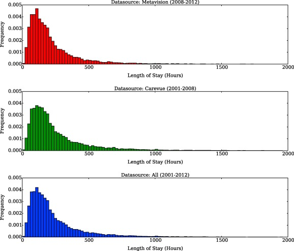

1. [Download : Download high-res image (310KB)](https://ars.els-cdn.com/content/image/1-s2.0-S1532046418300716-gr1_lrg.jpg)
2. [Download : Download full-size image](https://ars.els-cdn.com/content/image/1-s2.0-S1532046418300716-gr1.jpg)

Fig. 1. Distribution of length of stay. Values above 2000 h are not shown in the figure.

### 4.2. Prediction algorithms

In this section, we describe all the prediction algorithms and the scoring systems that we have used for benchmarking tasks on MIMIC-III datasets.

#### 4.2.1. Scoring methods

*SAPS-II.* SAPS-II [3] stands for Simplified Acute Physiology Score and it is a ICU scoring system designed to measure the severity of the disease for patients admitted to an ICU. A point score is calculated for each of the 12 physiological features mentioned in Table 4 and a final SAPS-II score *S* is obtained as the sum of all point scores. Note that SAPS-II score is calculated using the data collected within the first 24 h of an ICU admission. After SAPS-II score is obtained, the individual mortality prediction can be calculated as [30]:$logpdeath1-pdeath=-7.7631+0.0737·S+0.9971·log1+S$

*SOFA.* SOFA [23] is the Sepsis-related [Organ Failure Assessment score](https://www.sciencedirect.com/topics/medicine-and-dentistry/organ-dysfunction-score) (also referred to as the Sequential Organ Failure Assessment score) and it is used to describe organ dysfunction/failure of a patient in the ICU. The mortality prediction based on SOFA can be obtained by regressing the mortality on the SOFA score using a main-term logistic regression model.

*New SAPS-II.* A new SAPS-II scoring method was defined by Pirracchio [30]. It is a modified version of SAPS-II and is obtained by fitting a main-term logistic regression model using the same [explanatory variables](https://www.sciencedirect.com/topics/computer-science/explanatory-variable) as those used in the original SAPS-II score calculation.

#### 4.2.2. Super Learner models

Super Learner [45], [31] is a supervised learning algorithm that is designed to find the optimal combination from a set of prediction algorithms. It represents an asymptotically optimal learning system and is built on the theory of cross-validation. This algorithm requires a collection of user-defined machine learning algorithms such as logistic regression, regression trees, additive models, (shallow) [neural networks](https://www.sciencedirect.com/topics/computer-science/neural-network), and [random forest](https://www.sciencedirect.com/topics/computer-science/random-decision-forest). The algorithm then estimates the risk associated to each algorithm in the provided collection using cross-validation. One round of cross-validation involves partitioning a sample of data into complementary subsets, performing the analysis on one subset (called the training set), and validating the analysis on the other subset (called the validation set or testing set). To reduce variability, multiple rounds of cross-validation are performed using different partitions, and the validation results are averaged over the rounds. From this estimation of the risk associated with each candidate algorithm, the Super Learner builds an aggregate algorithm obtained as the optimal weighted combination of the candidate algorithms. Table 7 shows the algorithms used in the Super Learner algorithm [30] and their implementation available in the R and [Python languages](https://www.sciencedirect.com/topics/computer-science/python-language). In the experiments section, we will compare and discuss the results of Super Learner using these [programming languages](https://www.sciencedirect.com/topics/computer-science/programming-language). Following Pirracchio [30], we consider two variants of Super Learner algorithm, namely, Super Learner I: Super Learner with categorized variables, and Super Learner II: Super Learner with non-transformed variables. Note that Super Learner-I is applicable only for Feature set A, while Super Learner-II algorithm can be used with all the Feature sets A, B and C.

Table 7. Algorithms used in Super Learner with corresponding R packages and Python libraries.

| Algorithm | R packages | Python libraries |
| --- | --- | --- |
| Standard logistic regression | SL.glm | sklearn.linear_model.LogisticRegression |
| Logistic regression based on the AIC | SL.stepAIC | sklearn.linear_model.LassoLarsIC |
| Generalized additive model | SL.gam | l pygam.LinearGAM |
|  |  | pygam.LogisticGAM |
| Generalized linear model with penalized maximum likelihood | SL.glmnet | sklearn.linear_model.ElasticNet |
| Multivariate adaptive polynomial spline regression | SL.polymars | pyearth.Earth |
| Bayesian generalized linear model | SL.bayesglm | sklearn.linear_model.BayesianRidge |
| Generalized boosted regression model | SL.gbm | l sklearn.ensemble.GradientBoostingRegressor |
|  |  | sklearn.ensemble.GradientBoostingClassifier |
| Neural network | l SL.nnet | l sklearn.neural_network.MLPRegressor |
|  |  | sklearn.neural_network.MLPClassifier |
| Bagging classification trees | l SL.ipredbagg | l sklearn.ensemble.BaggingRegressor |
|  |  | sklearn.ensemble.BaggingClassifier |
| Pruned recursive partitioning and Regression Trees | SL.rpartPrune | – |
| Random forest | SL.randomForest | l sklearn.ensemble.RandomForestRegressor |
|  |  | sklearn.ensemble.RandomForestClassifier |
| Bayesian additive regression trees | SL.bartMachine | – |

#### 4.2.3. Deep Learning Models

Deep Learning Models (also called [Deep Neural Networks](https://www.sciencedirect.com/topics/computer-science/deep-neural-network) or Deep models) [46] have become a successful approach for automated extraction of complex data representations for end-to-end training. Deep models consist of a layered, hierarchical architectures of neurons for learning and representing data. The hierarchical learning architecture is motivated by [artificial intelligence](https://www.sciencedirect.com/topics/computer-science/artificial-intelligence) emulating the deep, layered learning process of the primary sensorial areas of the neocortex in the human brain, which automatically extracts features and abstractions from the underlying data [47], [48]. In a deep learning model, each neuron receives one or more inputs and sums them to produce an output (or activation). Each neuron in the hidden layers is assigned a weight that is considered for the outcome classification, but this weight is itself learned from its previous layers. The hidden layers thus can use multidimensional input data and introduce progressively non-linear weight combinations to the learning algorithm.

The main advantage of the deep learning approach is its ability to automatically learn good feature representations from raw data, and thus significantly reduce the effort of handcrafted feature engineering. In addition, deep models learn distributed representations of data, which enables generalization to new combinations of the values of learned features beyond those seen during the training process. Deep Learning models have yielded outstanding results in several applications, including speech recognition [49], [50], computer vision [51], [52], [53], and [natural language processing](https://www.sciencedirect.com/topics/computer-science/natural-language-processing) [54], [55], [56], [57]. Recent research has shown that deep learning methods achieve state-of-the-art performance in analyzing health-related data, such as ICU mortality prediction [6], phenotype discovery [7] and disease prediction [36]. These works have demonstrated the strong performance by deep learning models in health care applications, which significantly alleviates the tedious work on feature engineering and extraction. Here, we will first briefly introduce two types of deep models namely [Feedforward neural networks](https://www.sciencedirect.com/topics/computer-science/feedforward-neural-network) (FFN), which is a standard [neural network structure](https://www.sciencedirect.com/topics/computer-science/neural-network-architecture), and Recurrent Neural Networks (RNN) which is used for modeling sequence and time series data. After that, we will describe our proposed Multi-modal deep learning model, a combination of FFN and RNN, which will be used in the benchmarking experiments.

*Feedforward Neural Networks.* A multilayer [feedforward network](https://www.sciencedirect.com/topics/computer-science/feedforward-network) [58] (FFN) is a neural network with multiple nonlinear layers and possibly one prediction layer on the top to solve classification task. The first layer takes $X$ as the input, and the output of each layer is used as the input of the next layer. The transformation of each layer *l* can be written as$X(l+1)=f(l)(X(l))=s(l)W(l)X(l)+b(l)$where $W(l)$ and $b(l)$ are respectively the weight matrix and bias vector of layer *l*, and $s(l)$ is a nonlinear [activation function](https://www.sciencedirect.com/topics/computer-science/activation-function), which usually is a *[logistic sigmoid](https://www.sciencedirect.com/topics/computer-science/logistic-sigmoid)*, *tanh*, or *ReLU* [59] function. We optimize the cross-entropy or mean squared error prediction loss for classification or regression tasks respectively and get the prediction output from the topmost prediction layer.

*Recurrent Neural Networks.* Recurrent neural network (RNN) models have been shown to be successful at modeling sequences and time series data [60]. RNN with simple activations are incapable of capturing long [term dependencies](https://www.sciencedirect.com/topics/computer-science/term-dependency), and hence their variants such as [Long Short Term Memory](https://www.sciencedirect.com/topics/computer-science/long-short-term-memory-network) (LSTM) [43] and [Gated Recurrent Unit](https://www.sciencedirect.com/topics/computer-science/gated-recurrent-unit) (GRU) [61] have become popular due to their ability to capture long-term dependencies using memory and gating units. GRU can be considered as a simplified version of LSTM and it has been shown that GRU has similar performance compared to LSTM [62]. The structure of GRU is shown in Fig. 2(a). Let $xt∈RP$ denotes the variables at time *t*, where $1⩽t⩽T$. At each time *t*, GRU has a reset gate $rtj$ and an update gate $ztj$ for each of the hidden state $htj$. The update function of GRU is shown as follows:$zt=σWzxt+Uzht-1+bzrt=σWrxt+Urht-1+brh̃t=tanhWxt+U(rt⊙ht-1)+bht=(1-zt)⊙ht-1+zt⊙h̃t$where matrices $Wz$, $Wr$, $W$, $Uz$, $Ur$, $U$ and vectors $bz$, $br$, $b$ are model parameters.

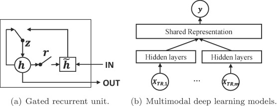

1. [Download : Download high-res image (168KB)](https://ars.els-cdn.com/content/image/1-s2.0-S1532046418300716-gr2_lrg.jpg)
2. [Download : Download full-size image](https://ars.els-cdn.com/content/image/1-s2.0-S1532046418300716-gr2.jpg)

Fig. 2. [Deep learning models](https://www.sciencedirect.com/topics/computer-science/deep-learning-model). In multimodal deep models, $X(.)$ represents the different inputs including temporal and non-temporal features, and *y* is the output.

*Multimodal Deep Learning Model (MMDL).* As our [benchmarking datasets](https://www.sciencedirect.com/topics/computer-science/benchmarking-dataset) come from multiple tables and includes both temporal and non-temporal data, multimodal deep learning models [63] can be used to shared learn representations for the prediction tasks. Here, we propose a deep learning framework called as Multimodal Deep Learning Model (MMDL) to learn shared representations from multiple modalities using an ensemble of FFN and GRU deep learning models. The key idea is to use a shared representation layer to capture the correlations of modalities or to learn a similarity of modalities in representation space, which is beneficial when limited data is available from multiple modalities. Data from each of the different tables can be treated as a separate modality. For simplicity, in MMDL, we treat all the temporal features as one modality and all non-temporal features as another modality. Fig. 2(b) shows an illustration of our MMDL framework with a common layer to learn the shared representations of modalities. MMDL uses FFN and GRU to handle non-temporal and temporal features respectively, and learns their shared latent representations for prediction tasks, i.e. the non-temporal data is fed into FFN and temporal data is input to GRU and then the outputs of the FFN and GRU are combined in a shared latent representation layer.

### 4.3. Implementation details

We implement the Super Learner algorithm using R packages and Python libraries listed in Table 7. The deep learning models are implemented in Theano [64] and [Keras](https://www.sciencedirect.com/topics/computer-science/keras) [65] platforms. For all the prediction methods, we conduct 5-fold cross validation(by training on three folds, validation on one fold and report results on the remaining fold) and report the mean and standard error of performance scores of all 5 testing folds. We use Area under the ROC curve (AUROC) and Area under Precision-Recall Curve (AUPRC) as the [evaluation metrics](https://www.sciencedirect.com/topics/computer-science/evaluation-metric) to report the prediction model’s performance on classification tasks, and use Mean Squared Error (MSE) to report results on the [regression task](https://www.sciencedirect.com/topics/computer-science/regression-task).

We use the [default parameters](https://www.sciencedirect.com/topics/computer-science/default-parameter) (as listed in their R package) for each [base algorithm](https://www.sciencedirect.com/topics/computer-science/base-algorithm) in the SuperLearner algorithm since we found through grid search that the performance did not vary much with fine-tuning of base algorithms with different parameter settings. For example, we did the grid search of Gradient Boosting Classifier by varying [learning rate](https://www.sciencedirect.com/topics/computer-science/learning-rate) [0.001, 0.01, 0.1], number of estimators [100,200,500] and max depth [3,6,9], and found that the AUC and AUPRC scores was best for the default parameters and their range was [0.841, 0.846] and [0.426, 0.435] respectively. Thus, we used default hyper parameters for the baseline algorithms of SuperLearner in all our experiments. Related work [30] which proposed SuperLearner algorithm for mortality prediction also used the default parameters to obtain their results.

All the deep learning models are trained with RMSProp optimizer method with learning rate of 0.001 on classification tasks and 0.005 on regression tasks. We used ReLU activation for all models since it is shown to achieve good performance in many classification tasks [66]. We also applied dropout with dropout rate set to 0.1 to all the deep learning models to avoid overfitting[67]. The batch size is chosen as 100 and the max epoch number is fixed at 250. Early stopping with best weight and [batch normalization](https://www.sciencedirect.com/topics/computer-science/batch-normalization) are applied during training. MMDL is a combination of FFN and GRU, in which FFN part handles non-temporal features and GRU part handles temporal features. The structure of MMDL used in our experiments is shown in Fig. A.7 in Appendix A.4.

All the data is divided to 5 folds with stratified cross validation, and standardization is done to the whole dataset with the mean and standard error of the training set. To enable reproducibility of our results, we have released our preprocessing codes and benchmark prediction task codes on Github.<sup>6</sup>

For SuperLearner, we have considered the feature statistics such as maximum, minimum, and mean as the representative values for each of the time series data since its lacking of the capability of handling serial data.

### 4.4. Results

In this section, we report the benchmarking results of all the prediction algorithms on the MIMIC-III datasets. We answer the following questions: (a) How do the Deep Learning models compare to the Super Learner algorithm and scoring systems? (b) What is the performance of prediction methods on the different feature sets?

#### 4.4.1. Performance of Super Learner algorithm implementations

First, we compare the performance of Super Learner-R and Super Learner-Python softwares on in-hospital mortality prediction task using feature set A i.e. 17 processed features collected in the first 24 h of ICU admission from MIMIC-III dataset. The result in Table 8 shows that Super Learner-Python performs slightly better than Super Leaner-R implementation. Moreover, Super Learner-Python can be evaluated significantly faster than Super Learner-R. Thus, in the following experiments, we will only report the results of Super Learner-Python version (unless otherwise stated) to evaluate and benchmark Super Learner algorithm on different tasks.

Table 8. Comparison of Super Learner-R and Super Learner-Python software versions on in-hospital mortality prediction task using Feature set A extracted from the first 24-h data of MIMIC-III. Running time refers to total time taken to perform cross-validation evaluation.

| Empty Cell | Empty Cell | AUROC score | AUPRC score | Running time |
| --- | --- | --- | --- | --- |
| SuperLearner-I | R version | 0.8402 ± 0.0021 | 0.4304 ± 0.0130 | 36 h |
|  | Python version | **0.8448** ± **0.0038** | **0.4351** ± **0.0139** | 30 min |
| SuperLearner-II | R version | 0.8646 ± 0.0023 | 0.4917 ± 0.0093 | 28 h |
|  | Python version | **0.8701** ± **0.0053** | **0.4991** ± **0.0107** | 25 min |

#### 4.4.2. Mortality prediction task evaluation

Here, we report the performance of all methods described in Section 4.2 on the mortality prediction tasks for benchmark datasets MIMIC-III and MIMIC-III (CareVue). We report the mean and standard deviation of AUROC and AUPRC for all the tasks.

Table 9. In-hospital mortality task on MIMIC-III using feature set A.

| Method | Algorithm | Feature Set A, 24-h data AUROC score | Feature Set A, 24-h data AUPRC score | Feature Set A, 48-h data AUROC score | Feature Set A, 48-h data AUPRC score |
| --- | --- | --- | --- | --- | --- |
| Score methods | SAPS-II | 0.8035 ± 0.0044 | 0.3586 ± 0.0052 | 0.8046 ± 0.0083 | 0.3373 ± 0.0141 |
|  | New SAPS-II | 0.8235 ± 0.0042 | 0.3989 ± 0.0120 | 0.8252 ± 0.0036 | 0.3823 ± 0.0119 |
|  | SOFA | 0.7322 ± 0.0038 | 0.3191 ± 0.0085 | 0.7347 ± 0.0094 | 0.2852 ± 0.0167 |
| Super Learner | SL.glm | 0.8235 ± 0.0042 | 0.3987 ± 0.0120 | 0.8251 ± 0.0037 | 0.3828 ± 0.0112 |
|  | SL.gbm | 0.8435 ± 0.0034 | 0.4320 ± 0.0125 | 0.8452 ± 0.0052 | 0.4163 ± 0.0121 |
|  | SL.nnet | 0.8388 ± 0.0044 | 0.4200 ± 0.0135 | 0.8381 ± 0.0055 | 0.3989 ± 0.0131 |
|  | SL.ipredbagg | 0.7556 ± 0.0064 | 0.3104 ± 0.0084 | 0.7510 ± 0.0078 | 0.2811 ± 0.0121 |
|  | SL.randomforest | 0.7576 ± 0.0085 | 0.3104 ± 0.0084 | 0.7538 ± 0.0095 | 0.2830 ± 0.0121 |
|  | SuperLearner-I | 0.8448 ± 0.0038 | 0.4351 ± 0.0139 | 0.8465 ± 0.0057 | 0.4190 ± 0.0124 |
|  | SL.glm | 0.8024 ± 0.0043 | 0.3804 ± 0.0043 | 0.8013 ± 0.0021 | 0.3559 ± 0.0238 |
|  | SL.gbm | 0.8628 ± 0.0037 | 0.4840 ± 0.0078 | 0.8518 ± 0.0049 | 0.4259 ± 0.0209 |
|  | SL.nnet | 0.8490 ± 0.0079 | 0.4587 ± 0.0058 | 0.8383 ± 0.0058 | 0.4028 ± 0.0180 |
|  | SL.ipredbagg | 0.8060 ± 0.0069 | 0.4087 ± 0.0110 | 0.7816 ± 0.0028 | 0.3455 ± 0.0159 |
|  | SL.randomforest | 0.7977 ± 0.0079 | 0.3958 ± 0.0124 | 0.7813 ± 0.0059 | 0.3496 ± 0.0200 |
|  | SuperLearner-II | **0.8673** ± **0.0045** | **0.4968** ± **0.0097** | 0.8595 ± 0.0035 | 0.4422 ± 0.0200 |
| Deep learning | FFN | 0.8496 ± 0.0047 | 0.4632 ± 0.0074 | 0.8375 ± 0.0041 | 0.4090 ± 0.0169 |
|  | RNN | 0.8544 ± 0.0053 | 0.4519 ± 0.0145 | 0.8618 ± 0.0059 | 0.4458 ± 0.0144 |
|  | MMDL | 0.8664 ± 0.0056 | 0.4776 ± 0.0162 | **0.8737** ± **0.0045** | **0.4714** ± **0.0176** |

Table 10. In-hospital mortality task on MIMIC-III (Carvue) using feature set A.

| Method | Algorithm | Feature Set A, 24-h data AUROC score | Feature Set A, 24-h data AUPRC score | Feature Set A, 48-h data AUROC score | Feature Set A, 48-h data AUPRC score |
| --- | --- | --- | --- | --- | --- |
| Score methods | SAPS-II | 0.8005 ± 0.0080 | 0.3625 ± 0.0065 | 0.8030 ± 0.0132 | 0.3448 ± 0.0219 |
|  | New SAPS-II | 0.8217 ± 0.0047 | 0.4037 ± 0.0069 | 0.8226 ± 0.0129 | 0.3873 ± 0.0163 |
|  | SOFA | 0.7263 ± 0.0100 | 0.3273 ± 0.0067 | 0.7309 ± 0.0105 | 0.2996 ± 0.0199 |
| Super Learner | SL.glm | 0.8212 ± 0.0052 | 0.4018 ± 0.0068 | 0.8227 ± 0.0132 | 0.3883 ± 0.0170 |
|  | SL.gbm | 0.8405 ± 0.0056 | 0.4377 ± 0.0112 | 0.8414 ± 0.0111 | 0.4187 ± 0.0315 |
|  | SL.nnet | 0.8332 ± 0.0041 | 0.4182 ± 0.0059 | 0.8309 ± 0.0061 | 0.3905 ± 0.0253 |
|  | SL.ipredbagg | 0.7567 ± 0.0040 | 0.3063 ± 0.0098 | 0.7483 ± 0.0167 | 0.2921 ± 0.0211 |
|  | SL.randomforest | 0.7553 ± 0.0058 | 0.3005 ± 0.0121 | 0.7538 ± 0.0150 | 0.2914 ± 0.0154 |
|  | SuperLearner-I | 0.8417 ± 0.0052 | 0.4387 ± 0.0122 | 0.8415 ± 0.0096 | 0.4169 ± 0.0305 |
|  | SL.glm | 0.8027 ± 0.0038 | 0.3931 ± 0.0105 | 0.8009 ± 0.0149 | 0.3683 ± 0.0209 |
|  | SL.gbm | 0.8581 ± 0.0062 | 0.4810 ± 0.0126 | 0.8457 ± 0.0080 | 0.4349 ± 0.0233 |
|  | SL.nnet | 0.8461 ± 0.0103 | 0.4674 ± 0.0173 | 0.8238 ± 0.0157 | 0.4017 ± 0.0412 |
|  | SL.ipredbagg | 0.7921 ± 0.0077 | 0.3850 ± 0.0180 | 0.7782 ± 0.0052 | 0.3434 ± 0.0213 |
|  | SL.randomforest | 0.7930 ± 0.0063 | 0.3830 ± 0.0091 | 0.7733 ± 0.0115 | 0.3455 ± 0.0253 |
|  | SuperLearner-II | **0.8651** ± **0.0075** | **0.4964** ± **0.0135** | 0.8520 ± 0.0101 | 0.4493 ± 0.0246 |
| Deep learning | FFN | 0.8488 ± 0.0082 | 0.4702 ± 0.0168 | 0.8326 ± 0.0112 | 0.4109 ± 0.0193 |
|  | RNN | 0.8456 ± 0.0032 | 0.4505 ± 0.0091 | 0.8485 ± 0.0090 | 0.4246 ± 0.0214 |
|  | MMDL | 0.8561 ± 0.0045 | 0.4764 ± 0.0144 | **0.8564** ± **0.0107** | **0.4520** ± **0.0305** |

Table 11, Table 12, Table 13, Table 14 show the in-hospital mortality prediction task results on Features set B and C of MIMIC-III and MIMIC-III (CareVue) datasets on the 24-h and 48-h data. We observe that: (i) Super Learner performs better than all algorithms used in SuperLearner library. (ii) On both the Feature Set B and Feature Set C, the deep learning model (MMDL) obtains the best results in terms of AUROC and AUPRC score. (iii) We can observe that the results on first 48-h data are similar with those on first 24-h data, showing that a longer record length helps little on the in-hospital mortality prediction task.

Table 11. In-hospital mortality task on MIMIC-III using feature set B.

| Method | Algorithm | Feature Set B, 24-h data AUROC score | Feature Set B, 24-h data AUPRC score | Feature Set B, 48-h data AUROC score | Feature Set B, 48-h data AUPRC score |
| --- | --- | --- | --- | --- | --- |
| Super Learner | SL.glm | 0.7745 ± 0.0055 | 0.3134 ± 0.0112 | 0.7869 ± 0.0015 | 0.3103 ± 0.0212 |
|  | SL.gbm | 0.8381 ± 0.0057 | 0.4059 ± 0.0156 | 0.8398 ± 0.0044 | 0.3932 ± 0.0155 |
|  | SL.nnet | 0.8170 ± 0.0036 | 0.3650 ± 0.0124 | 0.8232 ± 0.0074 | 0.3591 ± 0.0135 |
|  | SL.ipredbagg | 0.7641 ± 0.0070 | 0.3127 ± 0.0085 | 0.7627 ± 0.0118 | 0.3011 ± 0.0140 |
|  | SL.randomforest | 0.7582 ± 0.0080 | 0.3100 ± 0.0116 | 0.7604 ± 0.0042 | 0.2895 ± 0.0138 |
|  | SuperLearner-II | 0.8426 ± 0.0068 | 0.4160 ± 0.0136 | 0.8471 ± 0.0036 | 0.4055 ± 0.0155 |
| Deep learning | MMDL | **0.8730** ± **0.0065** | **0.4765** ± **0.0109** | **0.8783** ± **0.0037** | **0.4706** ± **0.0178** |

Table 12. In-hospital mortality task on MIMIC-III using feature set C.

| Method | Algorithm | Feature Set C, 24-h data AUROC score | Feature Set C, 24-h data AUPRC score | Feature Set C, 48-h data AUROC score | Feature Set C, 48-h data AUPRC score |
| --- | --- | --- | --- | --- | --- |
| Super Learner | SL.glm | 0.8341 ± 0.0072 | 0.4045 ± 0.0164 | 0.8594 ± 0.0079 | 0.4254 ± 0.0196 |
|  | SL.gbm | 0.8628 ± 0.0056 | 0.4705 ± 0.0138 | 0.8833 ± 0.0054 | 0.4954 ± 0.0223 |
|  | SL.nnet | 0.7568 ± 0.0106 | 0.3424 ± 0.0139 | 0.7973 ± 0.0060 | 0.3690 ± 0.0154 |
|  | SL.ipredbagg | 0.7895 ± 0.0077 | 0.3664 ± 0.0099 | 0.8074 ± 0.0100 | 0.3796 ± 0.0282 |
|  | SL.randomforest | 0.7720 ± 0.0054 | 0.3427 ± 0.0045 | 0.7945 ± 0.0081 | 0.3616 ± 0.0143 |
|  | SuperLearner-II | 0.8664 ± 0.0058 | 0.4821 ± 0.0142 | 0.8875 ± 0.0055 | 0.5059 ± 0.0214 |
| Deep learning | MMDL | **0.9410** ± **0.0082** | **0.7857** ± **0.0132** | **0.9401** ± **0.0099** | **0.7721** ± **0.0078** |

Table 13. In-hospital mortality task on MIMIC-III (CareVue) using feature set B.

| Method | Algorithm | Feature Set B, 24-h data AUROC score | Feature Set B, 24-h data AUPRC score | Feature Set B, 48-h data AUROC score | Feature Set B, 48-h data AUPRC score |
| --- | --- | --- | --- | --- | --- |
| Super Learner | SL.glm | 0.7724 ± 0.0129 | 0.3177 ± 0.0185 | 0.7872 ± 0.0139 | 0.3253 ± 0.0236 |
|  | SL.gbm | 0.8284 ± 0.0064 | 0.4048 ± 0.0110 | 0.8298 ± 0.0089 | 0.3823 ± 0.0189 |
|  | SL.nnet | 0.8133 ± 0.0060 | 0.3740 ± 0.0169 | 0.7976 ± 0.0201 | 0.3339 ± 0.0305 |
|  | SL.ipredbagg | 0.7525 ± 0.0066 | 0.3158 ± 0.0152 | 0.7536 ± 0.0136 | 0.2991 ± 0.0197 |
|  | SL.randomforest | 0.7497 ± 0.0118 | 0.3123 ± 0.0110 | 0.7502 ± 0.0094 | 0.2952 ± 0.0074 |
|  | SuperLearner-II | 0.8347 ± 0.0062 | 0.4164 ± 0.0148 | 0.8340 ± 0.0099 | 0.3907 ± 0.0128 |
| Deep learning | MMDL | **0.8617** ± **0.0074** | **0.4612** ± **0.0245** | **0.8633** ± **0.0080** | **0.4425** ± **0.0166** |

Table 14. In-hospital mortality task on MIMIC-III (CareVue) using feature set C.

| Method | Algorithm | Feature Set C, 24-h data AUROC score | Feature Set C, 24-h data AUPRC score | Feature Set C, 48-h data AUROC score | Feature Set C, 48-h data AUPRC score |
| --- | --- | --- | --- | --- | --- |
| Super Learner | SL.glm | 0.8282 ± 0.0089 | 0.3931 ± 0.0136 | 0.8497 ± 0.0088 | 0.4128 ± 0.0087 |
|  | SL.gbm | 0.8550 ± 0.0049 | 0.4605 ± 0.0209 | 0.8753 ± 0.0026 | 0.4846 ± 0.0042 |
|  | SL.nnet | 0.7412 ± 0.0067 | 0.3216 ± 0.0127 | 0.7946 ± 0.0132 | 0.3535 ± 0.0198 |
|  | SL.ipredbagg | 0.7737 ± 0.0064 | 0.3216 ± 0.0127 | 0.7976 ± 0.0065 | 0.3696 ± 0.0127 |
|  | SL.randomforest | 0.7690 ± 0.0080 | 0.3435 ± 0.0184 | 0.7900 ± 0.0101 | 0.3558 ± 0.0132 |
|  | SuperLearner-II | 0.8592 ± 0.0055 | 0.4694 ± 0.0207 | 0.8808 ± 0.0030 | 0.4945 ± 0.0054 |
| Deep learning | MMDL | **0.9200** ± **0.0213** | **0.7546** ± **0.0297** | **0.9251** ± **0.0120** | **0.7451** ± **0.0093** |

From the in-hospital mortality prediction task results, we make the following observations: (i) Deep learning models (MMDL) outperform all the other models when the raw features (Feature set B and C) are used for evaluation, (ii) All the models perform much better when more features are used for prediction, i.e. models perform better on Feature set C which has 136 raw features compared to Feature Set B which has 20 features. This implies that deep models can learn better feature representations from multiple data modalities (instead of using hand-picked features as in Feature Set A) which results in obtaining better prediction results on the in-hospital mortality benchmark task. The comparisons of SuperLearner-II and MMDL on three feature sets shown in Fig. 3, Fig. 4 validate our observations. From these figues, we see that on Feature set C, deep learning models obtain around 7–8% and 50% improvement over SuperLearner models for AUROC and AUPRC respectively. Also, deep learning models obtain 8% improvement for Feature set C compared to Feature set A.

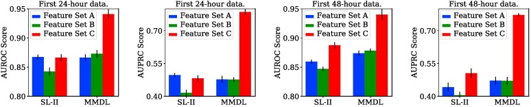

1. [Download : Download high-res image (291KB)](https://ars.els-cdn.com/content/image/1-s2.0-S1532046418300716-gr3_lrg.jpg)
2. [Download : Download full-size image](https://ars.els-cdn.com/content/image/1-s2.0-S1532046418300716-gr3.jpg)

Fig. 3. In-hospital mortality task on MIMIC-III data.

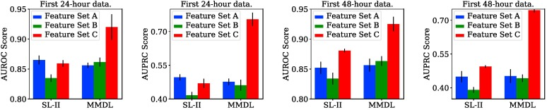

1. [Download : Download high-res image (292KB)](https://ars.els-cdn.com/content/image/1-s2.0-S1532046418300716-gr4_lrg.jpg)
2. [Download : Download full-size image](https://ars.els-cdn.com/content/image/1-s2.0-S1532046418300716-gr4.jpg)

Fig. 4. In-hospital mortality task on MIMIC-III (CareVue) data.

Table 15. AUROC scores of short-term and long-term mortality prediction tasks on MIMIC-III with 24-h data.

| Feature set | Algorithm | AUROC score 2-day Mortality | AUROC score 3-day Mortality | AUROC score 30-day Mortality | AUROC score 1-year Mortality |
| --- | --- | --- | --- | --- | --- |
| Feature Set A | SAPS-II Score | 0.8453 ± 0.0088 | 0.8218 ± 0.0057 | 0.7921 ± 0.0051 | 0.7614 ± 0.0035 |
|  | New SAPS-II Score | 0.8575 ± 0.0075 | 0.8370 ± 0.0053 | 0.8148 ± 0.0035 | 0.8042 ± 0.0013 |
|  | SOFA Score | 0.7559 ± 0.0276 | 0.7412 ± 0.0076 | 0.7041 ± 0.0074 | 0.6611 ± 0.0036 |
|  | SuperLearner-I | 0.8808 ± 0.0063 | 0.8627 ± 0.0079 | 0.8384 ± 0.0031 | 0.8260 ± 0.0019 |
|  | SuperLearner-II | 0.8851 ± 0.0105 | 0.8770 ± 0.0094 | 0.8620 ± 0.0063 | 0.8467 ± 0.0022 |
|  | FFN | 0.8673 ± 0.0069 | 0.8493 ± 0.0128 | 0.8475 ± 0.0050 | 0.8390 ± 0.0019 |
|  | RNN | 0.8773 ± 0.0117 | 0.8612 ± 0.0083 | 0.8326 ± 0.0085 | 0.7958 ± 0.0026 |
|  | MMDL | 0.8815 ± 0.0102 | 0.8725 ± 0.0063 | 0.8585 ± 0.0059 | 0.8450 ± 0.0019 |
| Feature Set B | SuperLearner-II | 0.8667 ± 0.0097 | 0.8535 ± 0.0128 | 0.8395 ± 0.0031 | 0.8347 ± 0.0046 |
|  | MMDL | 0.8862 ± 0.0059 | 0.8769 ± 0.0107 | 0.8620 ± 0.0072 | 0.8452 ± 0.0008 |
| Feature Set C | SuperLearner-II | 0.8837 ± 0.0047 | 0.8746 ± 0.0073 | 0.8629 ± 0.0033 | 0.8589 ± 0.0032 |
|  | MMDL | **0.9084** ± **0.0207** | **0.9295** ± **0.0225** | **0.9169** ± **0.0054** | **0.8872** ± **0.0084** |

Table 16. AUPRC scores of short-term and long-term mortality prediction tasks on MIMIC-III with 24-h data.

| Feature set | Algorithm | AUPRC score 2-day Mortality | AUPRC score 3-day Mortality | AUPRC score 30-day Mortality | AUPRC score 1-year Mortality |
| --- | --- | --- | --- | --- | --- |
| Feature Set A | SAPS-II Score | 0.1361 ± 0.0153 | 0.1730 ± 0.0214 | 0.4140 ± 0.0131 | 0.5084 ± 0.0154 |
|  | New SAPS-II Score | 0.1587 ± 0.0226 | 0.1919 ± 0.0234 | 0.4589 ± 0.0125 | 0.5778 ± 0.0109 |
|  | SOFA Score | 0.1027 ± 0.0278 | 0.1373 ± 0.0201 | 0.3497 ± 0.0167 | 0.4176 ± 0.0088 |
|  | SuperLearner-I | 0.1967 ± 0.0205 | 0.2219 ± 0.0263 | 0.5053 ± 0.0173 | 0.6258 ± 0.0073 |
|  | SuperLearner-II | 0.2463 ± 0.0111 | 0.2775 ± 0.0382 | 0.5652 ± 0.0186 | 0.6609 ± 0.0090 |
|  | FFN | 0.2429 ± 0.0332 | 0.2449 ± 0.0315 | 0.5367 ± 0.0199 | 0.6453 ± 0.0081 |
|  | RNN | 0.2491 ± 0.0293 | 0.2752 ± 0.0164 | 0.5028 ± 0.0178 | 0.5725 ± 0.0062 |
|  | MMDL | 0.2529 ± 0.0338 | 0.2839 ± 0.0207 | 0.5483 ± 0.0187 | 0.6485 ± 0.0099 |
| Feature Set B | SuperLearner-II | 0.1767 ± 0.0319 | 0.2173 ± 0.0266 | 0.4926 ± 0.0090 | 0.6328 ± 0.0100 |
|  | MMDL | 0.2475 ± 0.0364 | 0.1863 ± 0.0273 | 0.5458 ± 0.0231 | 0.6457 ± 0.0082 |
| Feature Set C | SuperLearner-II | 0.2048 ± 0.0085 | 0.2717 ± 0.0321 | 0.5530 ± 0.0096 | 0.6764 ± 0.0056 |
|  | MMDL | **0.3831** ± **0.0336** | **0.5139** ± **0.0193** | **0.7668** ± **0.0170** | **0.7690** ± **0.0077** |

Table 17. AUROC scores of short-term and long-term mortality prediction tasks on MIMIC-III with 48-h data.

| Feature set | Algorithm | AUROC score 3-day Mortality | AUROC score 30-day Mortality | AUROC score 1-year Mortality |
| --- | --- | --- | --- | --- |
| Feature Set A | SAPS-II Score | 0.8366 ± 0.0109 | 0.7841 ± 0.0072 | 0.7490 ± 0.0041 |
|  | New SAPS-II Score | 0.8471 ± 0.0072 | 0.8104 ± 0.0047 | 0.7991 ± 0.0037 |
|  | SOFA Score | 0.7465 ± 0.0179 | 0.6953 ± 0.0104 | 0.6454 ± 0.0052 |
|  | SuperLearner-I | 0.8675 ± 0.0046 | 0.8364 ± 0.0033 | 0.8222 ± 0.0047 |
|  | SuperLearner-II | 0.8706 ± 0.0095 | 0.8531 ± 0.0043 | 0.8409 ± 0.0031 |
|  | FFN | 0.8466 ± 0.0186 | 0.8385 ± 0.0061 | 0.8309 ± 0.0048 |
|  | RNN | 0.8633 ± 0.0116 | 0.8374 ± 0.0087 | 0.7966 ± 0.0036 |
|  | MMDL | 0.8596 ± 0.0124 | 0.8612 ± 0.0059 | 0.8418 ± 0.0049 |
| Feature Set B | SuperLearner-II | 0.8448 ± 0.0162 | 0.8427 ± 0.0071 | 0.8360 ± 0.0057 |
|  | MMDL | 0.8682 ± 0.0240 | 0.8628 ± 0.0111 | 0.8438 ± 0.0053 |
| Feature Set C | SuperLearner-II | 0.8473 ± 0.0114 | 0.8802 ± 0.0037 | 0.8673 ± 0.0051 |
|  | MMDL | **0.8713** ± **0.0494** | **0.9173** ± **0.0064** | **0.8702** ± **0.0054** |

Table 18. AUPRC scores of short-term and long-term mortality prediction tasks on MIMIC-III with 48-h data.

| Feature set | Algorithm | AUPRC score 3-day Mortality | AUPRC score 30-day Mortality | AUPRC score 1-year Mortality |
| --- | --- | --- | --- | --- |
| Feature Set A | SAPS-II Score | 0.1082 ± 0.0150 | 0.3849 ± 0.0118 | 0.4845 ± 0.0092 |
|  | New SAPS-II Score | 0.1307 ± 0.0225 | 0.4342 ± 0.0119 | 0.5647 ± 0.0090 |
|  | SOFA Score | 0.0663 ± 0.0092 | 0.3156 ± 0.0143 | 0.3898 ± 0.0115 |
|  | SuperLearner-I | 0.1344 ± 0.0247 | 0.4898 ± 0.0139 | 0.6171 ± 0.0088 |
|  | SuperLearner-II | 0.1955 ± 0.0245 | 0.5255 ± 0.0152 | 0.6448 ± 0.0084 |
|  | FFN | 0.1672 ± 0.0331 | 0.4962 ± 0.0153 | 0.6272 ± 0.0116 |
|  | RNN | **0.2371** ± **0.0336** | 0.4974 ± 0.0149 | 0.5691 ± 0.0080 |
|  | MMDL | 0.2131 ± 0.0344 | 0.5423 ± 0.0164 | 0.6421 ± 0.0116 |
| Feature Set B | SuperLearner-II | 0.1225 ± 0.0286 | 0.4892 ± 0.0197 | 0.6297 ± 0.0067 |
|  | MMDL | 0.1659 ± 0.0434 | 0.5290 ± 0.0372 | 0.6444 ± 0.0133 |
| Feature Set C | SuperLearner-II | 0.0771 ± 0.0125 | 0.5479 ± 0.0079 | 0.6870 ± 0.0038 |
|  | MMDL | 0.1510 ± 0.0246 | **0.7314** ± **0.0149** | **0.7344** ± **0.0062** |

#### 4.4.3. ICD-9 code prediction task evaluation

Table 19, Table 20 show the performance (AUPRC and AUROC scores) of all methods for the first 24-h data of MIMIC-III on ICD-9 code prediction task. We observe that the MMDL deep models trained on Feature Set C outperforms Super Learner models trained on Feature Sets A, B, and C on almost all the ICD-9 Code prediction task, and on an average obtains 4–5% improvement.

Table 19. ICD-9 code prediction AUPRC scores on MIMIC-III with first 24-h data.

| ICD-9 task | Super Learner Super Learner-I on Feature Set A | Super Learner Super Learner-II on Feature Set A | Super Learner Super Learner-II on Feature Set B | Super Learner Super Learner-II on Feature Set C | Deep learning FFN on Feature Set C | Deep learning RNN on Feature Set C | Deep learning MMDL on Feature Set C |
| --- | --- | --- | --- | --- | --- | --- | --- |
| 1 | 0.5356 ± 0.0027 | 0.5861 ± 0.0090 | 0.5695 ± 0.0075 | 0.6273 ± 0.0077 | 0.5807 ± 0.0072 | 0.5978 ± 0.0211 | **0.6491** ± **0.0121** |
| 2 | 0.7290 ± 0.0141 | 0.7512 ± 0.0130 | 0.7478 ± 0.0097 | 0.7756 ± 0.0134 | 0.7422 ± 0.0064 | 0.4715 ± 0.0132 | **0.8024** ± **0.0192** |
| 3 | 0.8095 ± 0.0057 | 0.8235 ± 0.0054 | 0.8302 ± 0.0057 | 0.8631 ± 0.0042 | 0.8377 ± 0.0055 | 0.8614 ± 0.0022 | **0.8690** ± **0.0115** |
| 4 | 0.5454 ± 0.0072 | 0.5850 ± 0.0065 | 0.5836 ± 0.0037 | 0.6882 ± 0.0128 | 0.6556 ± 0.0162 | 0.6812 ± 0.0125 | **0.7149** ± **0.0180** |
| 5 | 0.4714 ± 0.0047 | 0.5168 ± 0.0073 | 0.5218 ± 0.0044 | **0.5624** ± **0.0019** | 0.5058 ± 0.0100 | 0.5220 ± 0.0048 | 0.5590 ± 0.0212 |
| 6 | 0.4112 ± 0.0046 | 0.4348 ± 0.0064 | 0.4507 ± 0.0067 | 0.5155 ± 0.0074 | 0.4566 ± 0.0175 | 0.5261 ± 0.0076 | **0.5624** ± **0.0112** |
| 7 | 0.9547 ± 0.0026 | 0.9596 ± 0.0025 | 0.9585 ± 0.0019 | 0.9701 ± 0.0018 | 0.9592 ± 0.0013 | 0.9552 ± 0.0040 | **0.9729** ± **0.0021** |
| 8 | 0.6960 ± 0.0061 | 0.7366 ± 0.0045 | 0.7306 ± 0.0079 | 0.7649 ± 0.0038 | 0.7493 ± 0.0050 | 0.8067 ± 0.0062 | **0.8290** ± **0.0113** |
| 9 | 0.5814 ± 0.0080 | 0.6350 ± 0.0107 | 0.6326 ± 0.0087 | 0.6961 ± 0.0091 | 0.6393 ± 0.0033 | 0.6748 ± 0.0106 | **0.7034** ± **0.0148** |
| 10 | 0.7213 ± 0.0034 | 0.7442 ± 0.0047 | 0.7328 ± 0.0063 | 0.7928 ± 0.0053 | 0.7715 ± 0.0036 | 0.8071 ± 0.0020 | **0.8227** ± **0.0112** |
| 11 | 0.0700 ± 0.0180 | 0.0965 ± 0.0193 | 0.0857 ± 0.0082 | 0.2303 ± 0.0345 | 0.1498 ± 0.0565 | 0.1623 ± 0.0504 | **0.4888** ± **0.0631** |
| 12 | 0.1629 ± 0.0106 | 0.1802 ± 0.0109 | 0.1862 ± 0.0138 | 0.2146 ± 0.0213 | 0.1930 ± 0.0117 | 0.2019 ± 0.0149 | **0.3155** ± **0.0421** |
| 13 | 0.2436 ± 0.0070 | 0.2551 ± 0.0062 | 0.2554 ± 0.0051 | 0.3144 ± 0.0074 | 0.2641 ± 0.0078 | 0.2945 ± 0.0155 | **0.3435** ± **0.0293** |
| 14 | 0.1318 ± 0.0177 | 0.1357 ± 0.0219 | 0.1370 ± 0.0198 | 0.1329 ± 0.0183 | 0.1134 ± 0.0225 | 0.0775 ± 0.0068 | **0.1918** ± **0.0216** |
| 15 | 0.4745 ± 0.0061 | 0.5036 ± 0.0032 | 0.4908 ± 0.0061 | 0.5343 ± 0.0096 | 0.4848 ± 0.0096 | 0.5182 ± 0.0079 | **0.5564** ± **0.0195** |
| 16 | 0.1164 ± 0.0057 | 0.1279 ± 0.0082 | 0.1264 ± 0.0080 | 0.1711 ± 0.0097 | 0.1488 ± 0.0093 | 0.1433 ± 0.0104 | **0.2244** ± **0.0279** |
| 17 | 0.0632 ± 0.0113 | 0.0649 ± 0.0028 | 0.0736 ± 0.0048 | 0.0913 ± 0.0101 | 0.0742 ± 0.0055 | 0.0604 ± 0.0072 | **0.3700** ± **0.0577** |
| 18 | 0.5934 ± 0.0069 | 0.6302 ± 0.0053 | 0.6300 ± 0.0059 | 0.6826 ± 0.0072 | 0.6430 ± 0.0133 | 0.6675 ± 0.0068 | **0.7037** ± **0.0246** |
| 19 | 0.5946 ± 0.0029 | 0.6205 ± 0.0053 | 0.6361 ± 0.0065 | 0.7138 ± 0.0076 | 0.6684 ± 0.0041 | 0.6951 ± 0.0049 | **0.7184** ± **0.0086** |
| 20 | 0.4820 ± 0.0069 | 0.5220 ± 0.0128 | 0.5382 ± 0.0054 | 0.6006 ± 0.0103 | 0.5506 ± 0.0066 | 0.5723 ± 0.0041 | **0.6184** ± **0.0208** |
| Average | 0.4694 ± 0.0076 | 0.4955 ± 0.0083 | 0.4959 ± 0.0073 | 0.5471 ± 0.0102 | 0.5094 ± 0.0111 | 0.5148 ± 0.0107 | **0.6008** ± **0.0224** |

Table 20. ICD-9 code prediction AUROC scores on MIMIC-III with first 24-h data.

| ICD-9 task | Super Learner Super Learner-I on Feature Set A | Super Learner Super Learner-II on Feature Set A | Super Learner Super Learner-II on Feature Set B | Super Learner Super Learner-II on Feature Set C | Deep learning FFN on Feature Set C | Deep learning RNN on Feature Set C | Deep learning MMDL on Feature Set C |
| --- | --- | --- | --- | --- | --- | --- | --- |
| 1 | 0.7371 ± 0.0023 | 0.7757 ± 0.0049 | 0.7635 ± 0.0018 | 0.7971 ± 0.0044 | 0.7643 ± 0.0047 | 0.7879 ± 0.0133 | **0.8194** ± **0.0078** |
| 2 | 0.8342 ± 0.0091 | 0.8530 ± 0.0082 | 0.8472 ± 0.0056 | 0.8770 ± 0.0092 | 0.8467 ± 0.0062 | 0.7651 ± 0.0067 | **0.8912** ± **0.0154** |
| 3 | 0.6835 ± 0.0073 | 0.7022 ± 0.0070 | 0.7108 ± 0.0074 | 0.7532 ± 0.0061 | 0.7203 ± 0.0055 | 0.7460 ± 0.0059 | **0.7604** ± **0.0158** |
| 4 | 0.6714 ± 0.0052 | 0.7048 ± 0.0037 | 0.7038 ± 0.0023 | 0.7814 ± 0.0049 | 0.7575 ± 0.0067 | 0.7831 ± 0.0038 | **0.8048** ± **0.0131** |
| 5 | 0.6540 ± 0.0036 | 0.6833 ± 0.0047 | 0.6825 ± 0.0042 | 0.7163 ± 0.0036 | 0.6680 ± 0.0082 | 0.6921 ± 0.0032 | **0.7184** ± **0.0169** |
| 6 | 0.6222 ± 0.0028 | 0.6505 ± 0.0068 | 0.6526 ± 0.0027 | 0.7107 ± 0.0061 | 0.6651 ± 0.0071 | 0.7109 ± 0.0061 | **0.7387** ± **0.0122** |
| 7 | 0.8270 ± 0.0071 | 0.8457 ± 0.0067 | 0.8424 ± 0.0073 | 0.8753 ± 0.0060 | 0.8435 ± 0.0052 | 0.8339 ± 0.0068 | **0.8942** ± **0.0045** |
| 8 | 0.6976 ± 0.0049 | 0.7340 ± 0.0038 | 0.7315 ± 0.0066 | 0.7636 ± 0.0027 | 0.7447 ± 0.0029 | 0.7957 ± 0.0066 | **0.8148** ± **0.0093** |
| 9 | 0.6518 ± 0.0063 | 0.6980 ± 0.0093 | 0.6993 ± 0.0075 | 0.7512 ± 0.0107 | 0.7023 ± 0.0047 | 0.7298 ± 0.0102 | **0.7527** ± **0.0105** |
| 10 | 0.7807 ± 0.0024 | 0.7978 ± 0.0039 | 0.7881 ± 0.0041 | 0.8266 ± 0.0043 | 0.8089 ± 0.0016 | 0.8354 ± 0.0022 | **0.8512** ± **0.0105** |
| 11 | 0.9454 ± 0.0094 | 0.9635 ± 0.0060 | 0.9592 ± 0.0038 | **0.9692** ± **0.0081** | 0.8200 ± 0.0778 | 0.8268 ± 0.0322 | 0.9035 ± 0.0450 |
| 12 | 0.6340 ± 0.0151 | 0.6578 ± 0.0117 | 0.6638 ± 0.0161 | 0.6969 ± 0.0189 | 0.6670 ± 0.0068 | 0.6554 ± 0.0132 | **0.7378** ± **0.0141** |
| 13 | 0.5908 ± 0.0067 | 0.6078 ± 0.0049 | 0.6141 ± 0.0040 | 0.6727 ± 0.0055 | 0.6185 ± 0.0060 | 0.6409 ± 0.0088 | **0.6873** ± **0.0133** |
| 14 | 0.7170 ± 0.0172 | 0.7172 ± 0.0157 | 0.7204 ± 0.0211 | 0.7166 ± 0.0143 | 0.7003 ± 0.0128 | 0.6191 ± 0.0172 | **0.7346** ± **0.0251** |
| 15 | 0.6507 ± 0.0046 | 0.6774 ± 0.0048 | 0.6603 ± 0.0050 | 0.6938 ± 0.0028 | 0.6583 ± 0.0057 | 0.6897 ± 0.0063 | **0.7148** ± **0.0135** |
| 16 | 0.5901 ± 0.0156 | 0.6200 ± 0.0117 | 0.6176 ± 0.0144 | 0.6615 ± 0.0192 | 0.6243 ± 0.0121 | 0.6300 ± 0.0116 | **0.7011** ± **0.0207** |
| 17 | 0.6769 ± 0.0211 | 0.6917 ± 0.0094 | 0.6991 ± 0.0074 | 0.7530 ± 0.0236 | 0.6976 ± 0.0151 | 0.6144 ± 0.0223 | **0.8104** ± **0.0381** |
| 18 | 0.6405 ± 0.0076 | 0.6683 ± 0.0067 | 0.6676 ± 0.0066 | 0.7050 ± 0.0076 | 0.6722 ± 0.0115 | 0.7007 ± 0.0057 | **0.7319** ± **0.0240** |
| 19 | 0.6385 ± 0.0054 | 0.6619 ± 0.0068 | 0.6762 ± 0.0066 | **0.7358** ± **0.0052** | 0.6931 ± 0.0023 | 0.7127 ± 0.0019 | 0.7348 ± 0.0070 |
| 20 | 0.6263 ± 0.0071 | 0.6538 ± 0.0095 | 0.6656 ± 0.0043 | 0.7175 ± 0.0089 | 0.6719 ± 0.0053 | 0.7108 ± 0.0054 | **0.7426** ± **0.0136** |
| Average | 0.6935 ± 0.0080 | 0.7182 ± 0.0073 | 0.7183 ± 0.0069 | 0.7587 ± 0.0086 | 0.7172 ± 0.0104 | 0.7240 ± 0.0095 | **0.7772** ± **0.0165** |

#### 4.4.4. Length of stay prediction task evaluation

| Model and feature set |  | First 24-h data | First 48-h data |
| --- | --- | --- | --- |
| Super Learner | Super Learner-I on Feature Set A | 56420.6077 ± 3739.0173 | 58561.0081 ± 4223.1785 |
|  | Super Learner-II on Feature Set A | 54593.3317 ± 3265.8292 | 57454.7028 ± 4349.3598 |
|  | Super Learner-II on Feature Set B | 55844.4209 ± 3248.3224 | 54666.0875 ± 4859.4577 |
|  | Super Learner-II on Feature Set C | 54608.1099 ± 2923.9972 | 54400.5845 ± 1582.4523 |
| Deep learning | FFN on Feature Set C | 53410.0918 ± 3207.9849 | 52642.6508 ± 4373.4239 |
|  | RNN on Feature Set C | 48702.7641 ± 3768.5154 | 49556.8024 ± 3794.0471 |
|  | MMDL on Feature Set C | **36338.2015** ± **2672.3832** | **36924.2312** ± **3566.4318** |

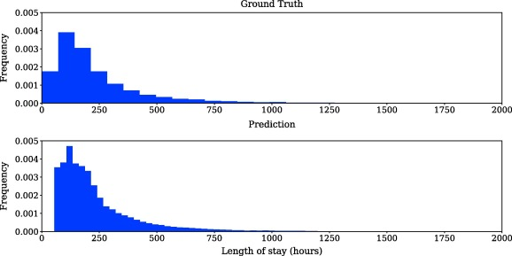

1. [Download : Download high-res image (171KB)](https://ars.els-cdn.com/content/image/1-s2.0-S1532046418300716-gr5_lrg.jpg)
2. [Download : Download full-size image](https://ars.els-cdn.com/content/image/1-s2.0-S1532046418300716-gr5.jpg)

Fig. 5. Comparision of the distribution with ground truth of lengths of stay predicted by [MMDL](https://www.sciencedirect.com/topics/computer-science/deep-learning-model) on Feature Set C with first 24-h data.

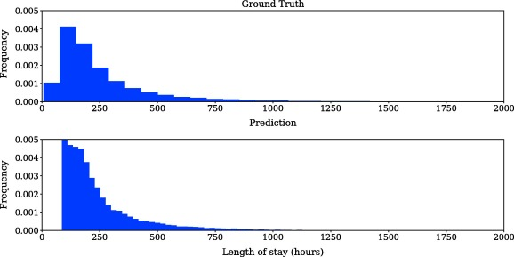

1. [Download : Download high-res image (162KB)](https://ars.els-cdn.com/content/image/1-s2.0-S1532046418300716-gr6_lrg.jpg)
2. [Download : Download full-size image](https://ars.els-cdn.com/content/image/1-s2.0-S1532046418300716-gr6.jpg)

Fig. 6. Comparision of the distribution with ground truth of lengths of stay predicted by MMDL on Feature Set C with first 48-h data.

#### 4.4.5. Statistical tests to compare performance of models

Table 22. [Pairwise comparisons](https://www.sciencedirect.com/topics/computer-science/pairwise-comparison) using Friedman’s test for multiple comparisons with [Bonferroni adjustment](https://www.sciencedirect.com/topics/computer-science/bonferroni-adjustment) of p-values (Bonferroni-Dunn procedure). Here, SL-I and SL-II correspond to SuperLearner-I and SuperLearner-II respectively; FS A, FS B, and FS C respectively correspond to Feature Set A, B and C. All deep learning models are evaluated on Feature Set C.

| Algorithm 1 | Algorithm 2 | Lower bound | Estimate | Upper bound | p-value for comparison |
| --- | --- | --- | --- | --- | --- |
| SL-I (FS A) | SL-II (FS A) | −2.588 | −1.660 | −0.732 | 1.16E−06 |
| SL-I (FS A) | SL-II (FS B) | −2.588 | −1.660 | −0.732 | 1.16E−06 |
| SL-I (FS A) | SL-II (FS C) | −5.358 | −4.430 | −3.502 | 2.52E−46 |
| SL-I (FS A) | FFN | −3.258 | −2.330 | −1.402 | 5.06E−13 |
| SL-I (FS A) | RNN | −3.898 | −2.970 | −2.042 | 5.12E−21 |
| SL-I (FS A) | MMDL | −6.428 | −5.500 | −4.572 | 3.88E−71 |
| SL-II (FS A) | SL-II (FS B) | −0.928 | 0.000 | 0.928 | 1.00E+00 |
| SL-II (FS A) | SL-II (FS C) | −3.698 | −2.770 | −1.842 | 2.57E−18 |
| SL-II (FS A) | FFN | −1.598 | −0.670 | 0.258 | 5.94E−01 |
| SL-II (FS A) | RNN | −2.238 | −1.310 | −0.382 | 3.79E−04 |
| SL-II (FS A) | MMDL | −4.768 | −3.840 | −2.912 | 6.54E−35 |
| SL-II (FS B) | SL-II (FS C) | −3.698 | −2.770 | −1.842 | 2.57E−18 |
| SL-II (FS B) | FFN | −1.598 | −0.670 | 0.258 | 5.94E−01 |
| SL-II (FS B) | RNN | −2.238 | −1.310 | −0.382 | 3.79E−04 |
| SL-II (FS B) | MMDL | −4.768 | −3.840 | −2.912 | 6.54E−35 |
| SL-II (FS C) | FFN | 1.172 | 2.100 | 3.028 | 1.31E−10 |
| SL-II (FS C) | RNN | 0.532 | 1.460 | 2.388 | 3.70E−05 |
| SL-II (FS C) | MMDL | −1.998 | −1.070 | −0.142 | 9.68E−03 |
| FFN | RNN | −1.568 | −0.640 | 0.288 | 7.60E−01 |
| FFN | MMDL | −4.098 | −3.170 | −2.242 | 6.68E−24 |
| RNN | MMDL | −3.458 | −2.530 | −1.602 | 2.56E−15 |

#### 4.4.6. Computation time

Our Python implementation of the Super Learner algorithm took about 25–30 min for evaluating the in-hospital mortality task using Feature Set A, and it took about 3 h for the Feature Set C. A deep Feed forward neural (FFN) network implemented using Keras took around 90 and 100 min for evaluating the same mortality task using Feature sets A and C respectively, while the MMDL model (shown in Fig. A.7 in Appendix A.4) took around 30 min and 1 h for Feature sets A and C respectively. All our experiments was run on a 32-core Intel(R) Xeon(R) CPU E5-2630 v3 @ 2.40 GHz machine with NVIDIA TITAN-X GPU processor.

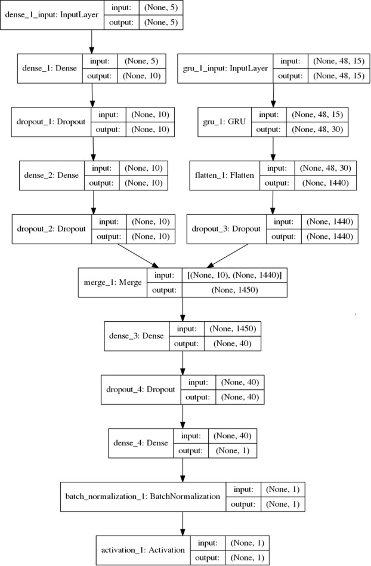

1. [Download : Download high-res image (477KB)](https://ars.els-cdn.com/content/image/1-s2.0-S1532046418300716-gr7_lrg.jpg)
2. [Download : Download full-size image](https://ars.els-cdn.com/content/image/1-s2.0-S1532046418300716-gr7.jpg)

Fig. A.7. Structure of the MMDL model with Feature Set B as input. Non-temporal features are fed to the [feed forward network](https://www.sciencedirect.com/topics/computer-science/feedforward-network) starting from “dense_1_input”, and temporal features are fed to the [RNN](https://www.sciencedirect.com/topics/computer-science/recurrent-neural-network) network starting from “gru_1_input” in the form of 2-D matrices (number of time steps X number of features). The word “None” in the figure refers to the batch size when training the deep learning models, which is 100 in our experiments. Numbers except “None” in one tuple describe the shape of the input/output tensor.

## 5. Summary

In this paper, we presented exhaustive benchmarking evaluation results of deep learning models, several machine learning models and ICU scoring systems on various clinical prediction tasks using the publicly available MIMIC-III datasets. We demonstrated that deep learning models consistently outperform all the other approaches especially when a large number of raw clinical time series data is used as input features to the prediction models.

## Acknowledgments

This material is based upon work supported by the NSF research Grants IIS-1134990, IIS-1254206, and Samsung GRO Grant. Any opinions, findings, and conclusions or recommendations expressed in this material are those of the author(s) and do not necessarily reflect the views of the funding agencies.

## Appendix A.

### A.1. Feature Set C

Table A.23 lists features in Feature Set C.

Table A.23. List of 136 features in Feature Set C.

| Feature name | Table name |
| --- | --- |
| Albumin 5% | inputevents |
| Fresh Frozen Plasma | inputevents |
| Lorazepam (Ativan) | inputevents |
| Calcium Gluconate | inputevents |
| Midazolam (Versed) | inputevents |
| Phenylephrine | inputevents |
| Furosemide (Lasix) | inputevents |
| Hydralazine | inputevents |
| Norepinephrine | inputevents |
| Magnesium Sulfate | inputevents |
| Nitroglycerin | inputevents |
| Insulin - Regular | inputevents |
| Morphine Sulfate | inputevents |
| Potassium Chloride | inputevents |
| Packed Red Blood Cells | inputevents |
| Gastric Meds | inputevents |
| D5 1/2NS | inputevents |
| LR | inputevents |
| Solution | inputevents |
| Sterile Water | inputevents |
| Piggyback | inputevents |
| OR Crystalloid Intake | inputevents |
| PO Intake | inputevents |
| GT Flush | inputevents |
| KCL (Bolus) | inputevents |
| Magnesium Sulfate (Bolus) | inputevents |
| epinephrine | inputevents |
| vasopressin | inputevents |
| dopamine | inputevents |
| midazolam | inputevents |

[output cut: 100 more lines]

### A.2. Mortality prediction task labels

The labels of in-hospital mortality are derived from table *ADMISSION*, in which the column *DEATHTIME* records either a valid death time of an admission if the patient dies in hospital or a null value if the patient dies after discharge. Therefore, we assign the in-hospital mortality label of an admission to 1 if its *DEATHTIME* is not null, else we assign the label to 0.

The labels of short-term mortality are generated with values in column *INTIME* from table *ICUSTAY*, which are in-time records of icu stays, and values in column *DOD* from table *PATIENTS*, which are records of death time of patients. We calculate the length of time interval between *INTIME* and *DOD* of an admission and assign its labels by comparing it with pre-defined lengths.

The labels of long-term mortality are generated with values in column *DISCHTIME* from table *ADMISSION*, which are in-time records of icu stays, and values in column *DOD* from table *PATIENTS*, which are records of death time of patients. We calculate the length of time interval between *INTIME* and *DOD* of an admission and assign its labels by comparing it with pre-defined lengths.

### A.3. Missing rates of feature sets

Table A.24, Table A.25, Table A.26 list the missing rates of features sets A, B, and C respectively.

Table A.24. Missing rates of Feature Set A for first 24 h and 48 h data.

| Feature | 24 h | 48 h |
| --- | --- | --- |
| glasgow_coma_scale | 0.676 | 0.712 |
| systolic_blood_pressure | 0.196 | 0.245 |
| heart_rate | 0.177 | 0.225 |
| body_temperature | 0.662 | 0.697 |
| pao2_fio2_ratio | 0.930 | 0.944 |
| urinary_output | 0.413 | 0.430 |
| serum_urea_nitrogen_level | 0.899 | 0.920 |
| white_blood_cells_count | 0.902 | 0.924 |
| serum_bicarbonate_level | 0.903 | 0.923 |
| sodium_level | 0.868 | 0.901 |
| potassium_level | 0.829 | 0.871 |
| bilirubin_level | 0.973 | 0.980 |

Table A.25. Missing rates of Feature Set B for first 24 h and 48 h data.

| Feature | 24 h | 48 h |
| --- | --- | --- |
| gcsverbal | 0.814 | 0.744 |
| gcsmotor | 0.814 | 0.744 |
| gcseyes | 0.813 | 0.743 |
| systolic_blood_pressure_abp_mean | 0.654 | 0.504 |
| heart_rate | 0.648 | 0.495 |
| body_temperature | 0.818 | 0.744 |
| pao2 | 0.928 | 0.932 |
| fio2 | 0.909 | 0.886 |
| urinary_output | 0.744 | 0.601 |
| serum_urea_nitrogen_level | 0.927 | 0.932 |
| white_blood_cells_count_mean | 0.930 | 0.936 |
| serum_bicarbonate_level_mean | 0.931 | 0.935 |
| sodium_level_mean | 0.907 | 0.917 |
| potassium_level_mean | 0.887 | 0.897 |
| bilirubin_level | 0.975 | 0.980 |

Table A.26. Missing rates of Feature Set C for first 24 h and 48 h data.

| Feature | 24 h | 48 h |
| --- | --- | --- |
| Gastric Gastric Tube | 0.996 | 0.995 |
| Stool Out Stool | 0.998 | 0.997 |
| Urine Out Incontinent | 0.995 | 0.995 |
| Ultrafiltrate Ultrafiltrate | 1.000 | 0.999 |
| Fecal Bag | 1.000 | 0.999 |
| Chest Tube 1 | 0.961 | 0.942 |
| Chest Tube 2 | 0.997 | 0.995 |
| Jackson Pratt 1 | 0.996 | 0.993 |
| OR EBL | 0.996 | 0.996 |
| Pre-Admission | 0.991 | 0.994 |
| TF Residual | 1.000 | 0.999 |
| Albumin 5% | 0.999 | 0.998 |
| Fresh Frozen Plasma | 0.995 | 0.996 |
| Lorazepam (Ativan) | 0.996 | 0.995 |
| Calcium Gluconate | 0.997 | 0.996 |
| Midazolam (Versed) | 0.995 | 0.995 |
| Phenylephrine | 0.979 | 0.971 |
| Furosemide (Lasix) | 0.998 | 0.996 |
| Hydralazine | 0.999 | 0.999 |
| Norepinephrine | 0.986 | 0.980 |
| Magnesium Sulfate | 0.989 | 0.990 |
| Nitroglycerin | 0.994 | 0.994 |
| Insulin - Regular | 0.989 | 0.984 |
| Morphine Sulfate | 0.993 | 0.991 |
| Potassium Chloride | 0.994 | 0.995 |
| Packed Red Blood Cells | 0.990 | 0.989 |
| Gastric Meds | 0.994 | 0.989 |
| D5 1/2NS | 0.998 | 0.998 |
| LR | 0.990 | 0.990 |
| Solution | 0.981 | 0.979 |

[output cut: 106 more lines]

### A.4. MMDL model

Fig. A.7 illustrates the structure of our proposed MMDL model for Feature Set B as the input.

### A.5. Distribution of the duplicates present in the database

Fig. A.8 shows the distribution of duplicates of all features present in the database. Most features appear as duplicates fewer than 50 times. All these duplicates where identified based on their time stamp and using simple natural language processing techniques, and they were removed if the entries were exactly similar, otherwise the latest entry is kept if there is a note in the database stating that the entry was updated. Otherwise, the duplicates were averaged or summed up depending on the feature.

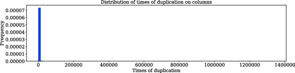

1. [Download : Download high-res image (109KB)](https://ars.els-cdn.com/content/image/1-s2.0-S1532046418300716-gr8_lrg.jpg)
2. [Download : Download full-size image](https://ars.els-cdn.com/content/image/1-s2.0-S1532046418300716-gr8.jpg)

Fig. A.8. Distribution of duplicates of all features. x-axis denotes the number of times duplicates appear in the database and y-axis represents the frequency of duplication of features.

### A.6. Inconsistency of feature sets and unit conversion

For the features with inconsistency in units, we performed the unit conversion using a set of rules as shown in Table A.27. First, we searched the feature name at this URL https://www.drugs.com/dosage/ to obtain the unit conversion rules as used in the medical community. For some of the features we were able to find the unit conversions at this URL. For*Fentanyl, TPA*, and *Ketamine* features, we obtained the range of values for each unit from the URL, and chose the unit conversion rule based on the statistics of the feature values, i.e. we compared the range of values for each unit and manually set proper conversion rules as listed in the Table. For some features such as *C-Reactive Protein*, and *DHEA-Sulfate*, we employed simple conversion rules since units of these features are comprised of standard units and can be converted based on standard rules. For example, 1 mIU/mL = 1000 mIU/L since 1000 mL = 1 L. For *Calcium Chloride* feature, we removed ml and only kept the mg unit.

Table A.27. Inconsistency of feature sets and unit conversion rules. The column -*Different units (% of major unit)* lists all the units for that feature along with the % of the major unit for that feature present in the database. For features with superscript *a*, the corresponding dosage was obtained from https://www.drugs.com/dosage/. For features with superscript *b*, a simple rules of unit conversion is employed. For features with *c*, only the majority unit values were kept. For features with superscript *d*, we compared the range of values in each unit and manually set proper conversion rules.

| Feature name | Different units (% of major unit) | Conversion rule |
| --- | --- | --- |
| Bivalirudin<sup>a</sup> | ml(52.13%), mg | 1 ml == 1 mg |
| Xigris<sup>a</sup> | ml(66.47%), mg | 5 mg == 2.5 ml |
| Azithromycin<sup>a</sup> | dose(66.47%), mg | 250 mg == 1dose |
| Isuprel<sup>a</sup> | ml(72.65%), mg | 0.2 mg == 1 ml |
| Solumedrol<sup>a</sup> | mg(73.28%), ml | 40 mg == 1 ml |
| Pantoprazole(Protonix)<sup>a</sup> | dose(75.12%), mg | 1dose == 40 mg |
| Fentanyl<sup>d</sup> | mcg(79.95%), mg | 1000 mcg == 1 mg |
| Promod<sup>a</sup> | tsp(82.37%), gm | 1tsp == 6.6 g |
| Ketamine<sup>d</sup> | mg(84.20%), ml | 1 mg == 1 ml |
| TPA<sup>d</sup> | mg(84.43%), ml | 1 mg == 1 ml |
| Sodium Acetate<sup>a</sup> | mEQ/mEq(86.73%), U, ml | 2 mEq/mEQ == 1 ml |
|  |  | 1U == 1 mEq/mEQ |
| Factor Vlla<sup>a</sup> | mcg(87.16%), dose, pg | 1dose == 5000mcg |
|  |  | 1 pg == 1 mcg |
| Coumadin(Warfarin)<sup>a</sup> | dose(88.26%), mg | 1dose == 4 mg |
| Calcium Chloride<sup>c</sup> | mg(89.86%), ml | Remove ml and only keep mg |
| Theophylline<sup>b</sup> | ug/ml(54.45%), ug/mL | Same unit, no conversion |
| Urobilinogen<sup>b</sup> | mg/dL(64.92%), EU/dL | 1EU/dL == 1 mg/dL |
| Uric Acid<sup>a</sup> | mg/dL(68.65%), MG/DL | Same unit, no conversion |
| Follicle Stimulating Hormone<sup>b</sup> | mIU/mL(75.86%), mIU/L | 1 mIU/mL == 1000 mIU/L |
| Luteinizing Hormone<sup>b</sup> | mIU/mL(76.32%), mIU/L | 1 mIU/mL == 1000 mIU/L |
| DHEA-Sulfate<sup>b</sup> | ug/dL(81.82%), nG/mL | 1nG/mL == 0.1ug/dL |
| C-Reactive Protein<sup>b</sup> | mg/L(83.34%), mg/dL, MG/DL | 1 mg/dL == 10 mg/L |
| Triglycerides<sup>b</sup> | mg/dL(85.67%), MG/DL | Same unit, no conversion |
| Troponin T<sup>b</sup> | ng/mL(86.29%), ng/ml | Same unit, no conversion |
| Testosterone<sup>b</sup> | pg/mL(86.96%), ng/dL | 1 pg/mL == 0.1 ng/dL |
| RBC, Ascites<sup>b</sup> | #/uL(88.43%), #/CU MM | 1uL == 1CU MM |
| Blasts<sup>b</sup> | #/uL(88.72%), #/CU MM | 1uL == 1CU MM |
| Thyroxine (T4), Free<sup>b</sup> | ng/dL(88.89%), ng/dl | Same unit, no conversion |
| Thyroid Stimulating Hormone<sup>b</sup> | uIU/mL(89.25%), uU/ML | Typo, no conversion |

## References

1. [1]

   Z. Che, S. Purushotham, K. Cho, D. Sontag, Y. Liu, Recurrent Neural Networks for Multivariate Time Series with Missing Values, 2016, arXiv preprint [arXiv:1606.01865](http://arxiv.org/abs/1606.01865).

   Google Scholar
2. [2]

   H. Harutyunyan, H. Khachatrian, D.C. Kale, A. Galstyan, Multitask Learning and Benchmarking with Clinical Time Series Data, 2017, arXiv preprint [arXiv:1703.07771](http://arxiv.org/abs/1703.07771).

   Google Scholar
3. [3]

   J.-R. Le Gall, S. Lemeshow, F. Saulnier

   A new simplified acute physiology score (saps ii) based on a european/north american multicenter study

   Jama, 270 (1993), pp. 2957-2963

   [CrossRef](https://doi.org/10.1001/jama.1993.03510240069035)Google Scholar
4. [4]

   J. Lee, D.J. Scott, M. Villarroel, G.D. Clifford, M. Saeed, R.G. Mark

   Open-access mimic-ii database for intensive care research

   2011 Annual International Conference of the IEEE Engineering in Medicine and Biology Society, EMBC, IEEE (2011), pp. 8315-8318

   [View in Scopus](https://www.scopus.com/inward/record.url?eid=2-s2.0-84861660228&partnerID=10&rel=R3.0.0)Google Scholar
5. [5]

   A.E. Johnson, T.J. Pollard, L. Shen, L.-W.H. Lehman, M. Feng, M. Ghassemi, B. Moody, P. Szolovits, L.A. Celi, R.G. Mark

   Mimic-iii, a freely accessible critical care database

   Scient. Data, 3 (2016)

   Google Scholar
6. [6]

   A.E. Johnson, T.J. Pollard, R.G. Mark, Reproducibility in critical care: a mortality prediction case study, in: Machine Learning for Healthcare Conference, 2017, 361–376.

   Google Scholar
7. [7]

   Z. Che, D. Kale, W. Li, M.T. Bahadori, Y. Liu

   Deep computational phenotyping

   Proceedings of the 21th ACM SIGKDD International Conference on Knowledge Discovery and Data Mining, ACM (2015), pp. 507-516

   [CrossRef](https://doi.org/10.1145/2783258.2783365)[View in Scopus](https://www.scopus.com/inward/record.url?eid=2-s2.0-84954158331&partnerID=10&rel=R3.0.0)[Google Scholar](https://scholar.google.com/scholar_lookup?title=Deep%20computational%20phenotyping&publication_year=2015&author=Z.%20Che&author=D.%20Kale&author=W.%20Li&author=M.T.%20Bahadori&author=Y.%20Liu)
8. [8]

   Z. Che, S. Purushotham, R. Khemani, Y. Liu, Interpretable deep models for icu outcome prediction, in: AMIA Annual Symposium Proceedings, vol. 2016, American Medical Informatics Association, 2016, p. 371.

   Google Scholar
9. [9]

   K.L. Caballero Barajas, R. Akella

   Dynamically modeling patient’s health state from electronic medical records: a time series approach

   Proceedings of the 21th ACM SIGKDD International Conference on Knowledge Discovery and Data Mining, ACM (2015), pp. 69-78

   [CrossRef](https://doi.org/10.1145/2783258.2783289)Google Scholar
10. [10]

    J. Calvert, Q. Mao, A.J. Rogers, C. Barton, M. Jay, T. Desautels, H. Mohamadlou, J. Jan, R. Das

    A computational approach to mortality prediction of alcohol use disorder inpatients

    Comp Biol Med, 75 (2016), pp. 74-79

    [View PDF](https://www.sciencedirect.com/science/article/pii/S0010482516301305/pdfft?md5=be48aea6d171dbbac1b3e681a1ab21f6&pid=1-s2.0-S0010482516301305-main.pdf)[View article](https://www.sciencedirect.com/science/article/pii/S0010482516301305)[View in Scopus](https://www.scopus.com/inward/record.url?eid=2-s2.0-84971255250&partnerID=10&rel=R3.0.0)Google Scholar
11. [11]

    L.A. Celi, S. Galvin, G. Davidzon, J. Lee, D. Scott, R. Mark

    A database-driven decision support system: customized mortality prediction

    J Personal Med, 2 (2012), pp. 138-148

    [CrossRef](https://doi.org/10.3390/jpm2040138)[View in Scopus](https://www.scopus.com/inward/record.url?eid=2-s2.0-84906228837&partnerID=10&rel=R3.0.0)Google Scholar
12. [12]

    M. Ghassemi, M.A. Pimentel, T. Naumann, T. Brennan, D.A. Clifton, P. Szolovits, M. Feng, A multivariate timeseries modeling approach to severity of illness assessment and forecasting in ICU with sparse, heterogeneous clinical data, in: AAAI, 2015, pp. 446–453.

    Google Scholar
13. [13]

    M. Ghassemi, T. Naumann, F. Doshi-Velez, N. Brimmer, R. Joshi, A. Rumshisky, P. Szolovits

    Unfolding physiological state: Mortality modelling in intensive care units

    Proceedings of the 20th ACM SIGKDD International Conference on Knowledge Discovery and Data Mining, ACM (2014), pp. 75-84

    [CrossRef](https://doi.org/10.1145/2623330.2623742)[View in Scopus](https://www.scopus.com/inward/record.url?eid=2-s2.0-84907029489&partnerID=10&rel=R3.0.0)Google Scholar
14. [14]

    M. Hoogendoorn, A. el Hassouni, K. Mok, M. Ghassemi, P. Szolovits

    Prediction using patient comparison vs. modeling: a case study for mortality prediction

    2016 IEEE 38th Annual International Conference of the Engineering in Medicine and Biology Society (EMBC), IEEE (2016), pp. 2464-2467

    [View in Scopus](https://www.scopus.com/inward/record.url?eid=2-s2.0-85009128708&partnerID=10&rel=R3.0.0)Google Scholar
15. [15]

    R. Joshi, P. Szolovits, Prognostic physiology: modeling patient severity in intensive care units using radial domain folding, in: AMIA Annual Symposium Proceedings, vol. 2012, American Medical Informatics Association, 2012, p. 1276.

    Google Scholar
16. [16]

    J. Lee, D.M. Maslove

    Customization of a severity of illness score using local electronic medical record data

    J. Intens. Care Med., 32 (2017), pp. 38-47

    [CrossRef](https://doi.org/10.1177/0885066615585951)[View in Scopus](https://www.scopus.com/inward/record.url?eid=2-s2.0-85001085996&partnerID=10&rel=R3.0.0)Google Scholar
17. [17]

    L.-W. Lehman, M. Saeed, W. Long, J. Lee, R. Mark, Risk stratification of icu patients using topic models inferred from unstructured progress notes, in: AMIA Annual Symposium Proceedings, vol. 2012, American Medical Informatics Association, 2012, p. 505.

    Google Scholar
18. [18]

    Y. Luo, Y. Xin, R. Joshi, L.A. Celi, P. Szolovits, Predicting icu mortality risk by grouping temporal trends from a multivariate panel of physiologic measurements, in: AAAI, 2016, pp. 42–50.

    Google Scholar
19. [19]

    S. Joshi, S. Gunasekar, D. Sontag, G. Joydeep, Identifiable phenotyping using constrained non-negative matrix factorization, in: Machine Learning for Healthcare Conference, 2016, pp. 17–41.

    Google Scholar
20. [20]

    J. Lee, D.M. Maslove, J.A. Dubin

    Personalized mortality prediction driven by electronic medical data and a patient similarity metric

    PloS One, 10 (2015), p. e0127428

    [CrossRef](https://doi.org/10.1371/journal.pone.0127428)[View in Scopus](https://www.scopus.com/inward/record.url?eid=2-s2.0-84929340147&partnerID=10&rel=R3.0.0)Google Scholar
21. [21]

    J. Lee

    Patient-specific predictive modeling using random forests: an observational study for the critically ill

    JMIR Med. Inf., 5 (2017)

    Google Scholar
22. [22]

    Y.-F. Luo, A. Rumshisky, Interpretable topic features for post-ICU mortality prediction, in: AMIA Annual Symposium Proceedings, vol. 2016, American Medical Informatics Association, 2016, p. 827.

    Google Scholar
23. [23]

    J.-L. Vincent, R. Moreno, J. Takala, S. Willatts, A. De Mendonça, H. Bruining, C. Reinhart, P. Suter, L. Thijs

    The sofa (sepsis-related organ failure assessment) score to describe organ dysfunction/failure

    Intens. Care Med., 22 (1996), pp. 707-710

    [View in Scopus](https://www.scopus.com/inward/record.url?eid=2-s2.0-0030015661&partnerID=10&rel=R3.0.0)Google Scholar
24. [24]

    W.A. Knaus, J.E. Zimmerman, D.P. Wagner, E.A. Draper, D.E. Lawrence

    Apache-acute physiology and chronic health evaluation: a physiologically based classification system

    Crit. Care Med., 9 (1981), pp. 591-597

    [CrossRef](https://doi.org/10.1097/00003246-198108000-00008)[View in Scopus](https://www.scopus.com/inward/record.url?eid=2-s2.0-0019602768&partnerID=10&rel=R3.0.0)Google Scholar
25. [25]

    R. Dybowski, V. Gant, P. Weller, R. Chang

    Prediction of outcome in critically ill patients using artificial neural network synthesised by genetic algorithm

    The Lancet, 347 (1996), pp. 1146-1150

    [View PDF](https://www.sciencedirect.com/science/article/pii/S0140673696906091/pdf?md5=aeaac6d51f05a3f89c82386adb77b3e5&pid=1-s2.0-S0140673696906091-main.pdf)[View article](https://www.sciencedirect.com/science/article/pii/S0140673696906091)[View in Scopus](https://www.scopus.com/inward/record.url?eid=2-s2.0-0030603526&partnerID=10&rel=R3.0.0)Google Scholar
26. [26]

    S. Kim, W. Kim, R.W. Park

    A comparison of intensive care unit mortality prediction models through the use of data mining techniques

    Health. Inf. Res., 17 (2011), pp. 232-243

    [CrossRef](https://doi.org/10.4258/hir.2011.17.4.232)[View in Scopus](https://www.scopus.com/inward/record.url?eid=2-s2.0-84875784410&partnerID=10&rel=R3.0.0)Google Scholar
27. [27]

    J.V. Tu, M.R. Guerriere

    Use of a neural network as a predictive instrument for length of stay in the intensive care unit following cardiac surgery

    Comp. Biomed. Res., 26 (1993), pp. 220-229

    [View PDF](https://www.sciencedirect.com/science/article/pii/S0010480983710153/pdf?md5=874f39ddb297f3cdc71571e971a9732e&pid=1-s2.0-S0010480983710153-main.pdf)[View article](https://www.sciencedirect.com/science/article/pii/S0010480983710153)[View in Scopus](https://www.scopus.com/inward/record.url?eid=2-s2.0-0027288642&partnerID=10&rel=R3.0.0)Google Scholar
28. [28]

    G. Doig, K. Inman, W. Sibbald, C. Martin, J. Robertson, Modeling mortality in the intensive care unit: comparing the performance of a back-propagation, associative-learning neural network with multivariate logistic regression, in: Proceedings of the Annual Symposium on Computer Application in Medical Care, American Medical Informatics Association, 1993, p. 361.

    Google Scholar
29. [29]

    C.W. Hanson III, B.E. Marshall

    Artificial intelligence applications in the intensive care unit

    Crit. Care Med., 29 (2001), pp. 427-435

    [View in Scopus](https://www.scopus.com/inward/record.url?eid=2-s2.0-0035113477&partnerID=10&rel=R3.0.0)[Google Scholar](https://scholar.google.com/scholar_lookup?title=Artificial%20intelligence%20applications%20in%20the%20intensive%20care%20unit&publication_year=2001&author=C.W.%20Hanson%20III&author=B.E.%20Marshall)
30. [30]

    R. Pirracchio

    Mortality prediction in the ICU based on mimic-ii results from the super ICU learner algorithm (SICULA) project

    Secondary Analysis of Electronic Health Records, Springer (2016), pp. 295-313

    [CrossRef](https://doi.org/10.1007/978-3-319-43742-2_20)[View in Scopus](https://www.scopus.com/inward/record.url?eid=2-s2.0-85024394244&partnerID=10&rel=R3.0.0)Google Scholar
31. [31]

    E.C. Polley, M.J. Van der Laan, Super Learner in Prediction, U.C. Berkeley Division of Biostatistics Working Paper Series, 2010.

    Google Scholar
32. [32]

    R. Caruana, S. Baluja, T. Mitchell, Using the future to sort out the present: Rankprop and multitask learning for medical risk evaluation, in: Advances in Neural Information Processing Systems, 1996, pp. 959–965.

    Google Scholar
33. [33]

    G.F. Cooper, C.F. Aliferis, R. Ambrosino, J. Aronis, B.G. Buchanan, R. Caruana, M.J. Fine, C. Glymour, G. Gordon, B.H. Hanusa, *et al.*

    An evaluation of machine-learning methods for predicting pneumonia mortality

    Artif. Intell. Med., 9 (1997), pp. 107-138

    [View PDF](https://www.sciencedirect.com/science/article/pii/S0933365796003673/pdf?md5=ac3b96438465bd2aa37c6f973c477d31&pid=1-s2.0-S0933365796003673-main.pdf)[View article](https://www.sciencedirect.com/science/article/pii/S0933365796003673)[View in Scopus](https://www.scopus.com/inward/record.url?eid=2-s2.0-0031080885&partnerID=10&rel=R3.0.0)Google Scholar
34. [34]

    T.A. Lasko, J.C. Denny, M.A. Levy

    Computational phenotype discovery using unsupervised feature learning over noisy, sparse, and irregular clinical data

    PloS One, 8 (2013), p. e66341

    [CrossRef](https://doi.org/10.1371/journal.pone.0066341)[View in Scopus](https://www.scopus.com/inward/record.url?eid=2-s2.0-84879468407&partnerID=10&rel=R3.0.0)Google Scholar
35. [35]

    A. Oellrich, N. Collier, T. Groza, D. Rebholz-Schuhmann, N. Shah, O. Bodenreider, M.R. Boland, I. Georgiev, H. Liu, K. Livingston, *et al.*

    The digital revolution in phenotyping

    Brief. Bioinf. (2015), p. bbv083

    Google Scholar
36. [36]

    Z. Che, S. Purushotham, R. Khemani, Y. Liu, Distilling Knowledge From Deep Networks with Applications to Healthcare Domain, 2015 arXiv preprint [arXiv:1512.03542](http://arxiv.org/abs/1512.03542).

    Google Scholar
37. [37]

    F. Dabek, J.J. Caban

    A neural network based model for predicting psychological conditions

    Brain Informatics and Health, Springer (2015), pp. 252-261

    [CrossRef](https://doi.org/10.1007/978-3-319-23344-4_25)[View in Scopus](https://www.scopus.com/inward/record.url?eid=2-s2.0-84945954195&partnerID=10&rel=R3.0.0)[Google Scholar](https://scholar.google.com/scholar_lookup?title=A%20neural%20network%20based%20model%20for%20predicting%20psychological%20conditions&publication_year=2015&author=F.%20Dabek&author=J.J.%20Caban)
38. [38]

    N.Y. Hammerla, J.M. Fisher, P. Andras, L. Rochester, R. Walker, T. Plötz, Pd disease state assessment in naturalistic environments using deep learning, in: Twenty-Ninth AAAI Conference on Artificial Intelligence, 2015, pp. 1742–1748.

    Google Scholar
39. [39]

    Z.C. Lipton, D.C. Kale, C. Elkan, R. Wetzell, Learning to Diagnose with LSTM Recurrent Neural Networks, 2015 arXiv preprint [arXiv:1511.03677](http://arxiv.org/abs/1511.03677).

    Google Scholar
40. [40]

    S. Purushotham, W. Carvalho, T. Nilanon, Y. Liu, Variational recurrent adversarial deep domain adaptation, in: International Conference on Learning Representations (ICLR), 2017.

    Google Scholar
41. [41]

    H.L. Li-wei, R.P. Adams, L. Mayaud, G.B. Moody, A. Malhotra, R.G. Mark, S. Nemati

    A physiological time series dynamics-based approach to patient monitoring and outcome prediction

    IEEE J. Biomed. Health Inf., 19 (2015), pp. 1068-1076

    Google Scholar
42. [42]

    J. Lee

    Patient-specific predictive modeling using random forests: an observational study for the critically ill

    JMIR Med. Inf., 5 (2017)

    Google Scholar
43. [43]

    S. Hochreiter, J. Schmidhuber

    Long short-term memory

    Neural Comput., 9 (1997), pp. 1735-1780

    [CrossRef](https://doi.org/10.1162/neco.1997.9.8.1735)[View in Scopus](https://www.scopus.com/inward/record.url?eid=2-s2.0-0031573117&partnerID=10&rel=R3.0.0)[Google Scholar](https://scholar.google.com/scholar_lookup?title=Long%20short-term%20memory&publication_year=1997&author=S.%20Hochreiter&author=J.%20Schmidhuber)
44. [44]

    I. Silva, G. Moody, D.J. Scott, L.A. Celi, R.G. Mark, Predicting in-hospital mortality of ICU patients: the physionet/computing in cardiology challenge 2012, in: Computing in Cardiology (CinC), 2012, IEEE, 2012, pp. 245–248.

    Google Scholar
45. [45]

    M.J. Van der Laan, E.C. Polley, A.E. Hubbard

    Super learner

    Statist. Appl. Genet. Molec. Biol., 6 (2007)

    [Google Scholar](https://scholar.google.com/scholar_lookup?title=Super%20learner&publication_year=2007&author=M.J.%20Van%20der%20Laan&author=E.C.%20Polley&author=A.E.%20Hubbard)
46. [46]

    Y. LeCun, Y. Bengio, G. Hinton

    Deep learning

    Nature, 521 (2015), pp. 436-444

    [CrossRef](https://doi.org/10.1038/nature14539)[View in Scopus](https://www.scopus.com/inward/record.url?eid=2-s2.0-84930630277&partnerID=10&rel=R3.0.0)[Google Scholar](https://scholar.google.com/scholar_lookup?title=Deep%20learning&publication_year=2015&author=Y.%20LeCun&author=Y.%20Bengio&author=G.%20Hinton)
47. [47]

    H. Larochelle, Y. Bengio, J. Louradour, P. Lamblin

    Exploring strategies for training deep neural networks

    J. Mach. Learn. Res., 10 (2009), pp. 1-40

    [View in Scopus](https://www.scopus.com/inward/record.url?eid=2-s2.0-59449087310&partnerID=10&rel=R3.0.0)Google Scholar
48. [48]

    Y. Bengio, A. Courville, P. Vincent

    Representation learning: a review and new perspectives

    IEEE Trans. Patt. Anal. Mach. Intell., 35 (2013), pp. 1798-1828

    [View in Scopus](https://www.scopus.com/inward/record.url?eid=2-s2.0-84879854889&partnerID=10&rel=R3.0.0)[Google Scholar](https://scholar.google.com/scholar_lookup?title=Representation%20learning%3A%20a%20review%20and%20new%20perspectives&publication_year=2013&author=Y.%20Bengio&author=A.%20Courville&author=P.%20Vincent)
49. [49]

    G. Dahl, A.-r. Mohamed, G.E. Hinton, et al, Phone recognition with the mean-covariance restricted boltzmann machine, in: Advances in Neural Information Processing Systems, 2010, pp. 469–477.

    Google Scholar
50. [50]

    G.E. Dahl, D. Yu, L. Deng, A. Acero

    Context-dependent pre-trained deep neural networks for large-vocabulary speech recognition

    IEEE Trans. Audio, Speech, Lang. Process., 20 (2012), pp. 30-42

    [View in Scopus](https://www.scopus.com/inward/record.url?eid=2-s2.0-84055222005&partnerID=10&rel=R3.0.0)Google Scholar
51. [51]

    A. Krizhevsky, I. Sutskever, G.E. Hinton, Imagenet classification with deep convolutional neural networks, in: Advances in Neural Information Processing Systems, 2012, pp. 1097–1105.

    Google Scholar
52. [52]

    Y. Jia, E. Shelhamer, J. Donahue, S. Karayev, J. Long, R. Girshick, S. Guadarrama, T. Darrell

    Caffe: convolutional architecture for fast feature embedding

    Proceedings of the 22nd ACM International Conference on Multimedia, ACM (2014), pp. 675-678

    [CrossRef](https://doi.org/10.1145/2647868.2654889)Google Scholar
53. [53]

    C. Szegedy, W. Liu, Y. Jia, P. Sermanet, S. Reed, D. Anguelov, D. Erhan, V. Vanhoucke, A. Rabinovich, Going deeper with convolutions, in: Proceedings of the IEEE Conference on Computer Vision and Pattern Recognition, 2015, pp. 1–9.

    Google Scholar
54. [54]

    T. Mikolov, A. Deoras, S. Kombrink, L. Burget, J. Černockỳ, Empirical evaluation and combination of advanced language modeling techniques, in: Twelfth Annual Conference of the International Speech Communication Association, 2011, pp. 605–608.

    Google Scholar
55. [55]

    A. Bordes, X. Glorot, J. Weston, Y. Bengio, Joint learning of words and meaning representations for open-text semantic parsing, in: Artificial Intelligence and Statistics, 2012, pp. 127–135.

    Google Scholar
56. [56]

    T. Mikolov, W.-T. Yih, G. Zweig, Linguistic regularities in continuous space word representations, in: hlt-Naacl, vol. 13, 2013, pp. 746–751.

    Google Scholar
57. [57]

    T. Mikolov, I. Sutskever, K. Chen, G.S. Corrado, J. Dean, Distributed representations of words and phrases and their compositionality, in: Advances in Neural Information Processing Systems, 2013, pp. 3111–3119.

    Google Scholar
58. [58]

    K. Hornik, M. Stinchcombe, H. White

    Multilayer feedforward networks are universal approximators

    Neural Netw., 2 (1989), pp. 359-366

    [View PDF](https://www.sciencedirect.com/science/article/pii/0893608089900208/pdf?md5=f37408d30b45e2b222a745e88d8f311c&pid=1-s2.0-0893608089900208-main.pdf)[View article](https://www.sciencedirect.com/science/article/pii/0893608089900208)[View in Scopus](https://www.scopus.com/inward/record.url?eid=2-s2.0-0024880831&partnerID=10&rel=R3.0.0)[Google Scholar](https://scholar.google.com/scholar_lookup?title=Multilayer%20feedforward%20networks%20are%20universal%20approximators&publication_year=1989&author=K.%20Hornik&author=M.%20Stinchcombe&author=H.%20White)
59. [59]

    V. Nair, G.E. Hinton, Rectified linear units improve restricted boltzmann machines, in: Proceedings of the 27th International Conference on Machine Learning (ICML), 2010, pp. 807–814.

    Google Scholar
60. [60]

    R.J. Williams, D. Zipser

    A learning algorithm for continually running fully recurrent neural networks

    Neural Comput., 1 (1989), pp. 270-280

    [CrossRef](https://doi.org/10.1162/neco.1989.1.2.270)[Google Scholar](https://scholar.google.com/scholar_lookup?title=A%20learning%20algorithm%20for%20continually%20running%20fully%20recurrent%20neural%20networks&publication_year=1989&author=R.J.%20Williams&author=D.%20Zipser)
61. [61]

    K. Cho, B. van Merriënboer, D. Bahdanau, Y. Bengio, On the Properties of Neural Machine Translation: Encoder-Decoder Approaches, 2014, arXiv preprint [arXiv:1409.1259](http://arxiv.org/abs/1409.1259).

    Google Scholar
62. [62]

    J. Chung, C. Gulcehre, K. Cho, Y. Bengio, Empirical Evaluation of Gated Recurrent Neural Networks on Sequence Modeling, 2014 arXiv preprint [arXiv:1412.3555](http://arxiv.org/abs/1412.3555).

    Google Scholar
63. [63]

    N. Srivastava, R.R. Salakhutdinov, Multimodal learning with deep boltzmann machines, in: Advances in Neural Information Processing Systems, 2012, pp. 2222–2230.

    Google Scholar
64. [64]

    F. Bastien, P. Lamblin, R. Pascanu, J. Bergstra, I. Goodfellow, A. Bergeron, N. Bouchard, D. Warde-Farley, Y. Bengio, Theano: New Features and Speed Improvements, 2012, arXiv preprint [arXiv:1211.5590](http://arxiv.org/abs/1211.5590).

    Google Scholar
65. [65]

    F. Chollet, Keras: Theano-Based Deep Learning Library, 2015 Code: https://github.com/fchollet. Documentation: http://keras.io.

    Google Scholar
66. [66]

    B. Xu, N. Wang, T. Chen, M. Li, Empirical Evaluation of Rectified Activations in Convolutional Network, 2015 arXiv preprint [arXiv:1505.00853](http://arxiv.org/abs/1505.00853).

    Google Scholar
67. [67]

    N. Srivastava, G.E. Hinton, A. Krizhevsky, I. Sutskever, R. Salakhutdinov

    Dropout: a simple way to prevent neural networks from overfitting

    J. Mach. Learn. Res., 15 (2014), pp. 1929-1958

    [View in Scopus](https://www.scopus.com/inward/record.url?eid=2-s2.0-84904163933&partnerID=10&rel=R3.0.0)Google Scholar
68. [68]

    J. Luengo, S. García, F. Herrera

    A study on the use of statistical tests for experimentation with neural networks: analysis of parametric test conditions and non-parametric tests

    Expert Syst. Appl., 36 (2009), pp. 7798-7808

    [View PDF](https://www.sciencedirect.com/science/article/pii/S0957417408008646/pdfft?md5=a215416fcb88c7753b0f57adc9306deb&pid=1-s2.0-S0957417408008646-main.pdf)[View article](https://www.sciencedirect.com/science/article/pii/S0957417408008646)[View in Scopus](https://www.scopus.com/inward/record.url?eid=2-s2.0-60249094201&partnerID=10&rel=R3.0.0)Google Scholar

## Cited by (268)

### [A new efficient ALignment-driven Neural Network for Mortality Prediction from Irregular Multivariate Time Series data[Formula presented]](https://www.sciencedirect.com/science/article/pii/S0957417423026507)

- 2024, Expert Systems with Applications

### [Multi-organ spatiotemporal information aware model for sepsis mortality prediction](https://www.sciencedirect.com/science/article/pii/S0933365723002609)

- 2024, Artificial Intelligence in Medicine

  Compared with the baseline models for predicting mortality of sepsis, the rGAT-mGRU model demonstrated the largest area under the receiver operating characteristic curve (AUROC) of 0.8777 0.0039 and the maximum area under the precision-recall curve (AUPRC) of 0.5818 0.0071, with sensitivity of 0.8358 0.0302 and specificity of 0.7727 0.0229, respectively. The proposed model was capable of delineating the varying contribution of the involved organ systems at distinct moments, as specifically illustrated by the attention weights. Furthermore, it exhibited consistent performance even in the face of limited clinical data.

### [Evaluation of deep learning-based depression detection using medical claims data](https://www.sciencedirect.com/science/article/pii/S0933365723002592)

- 2024, Artificial Intelligence in Medicine

### [Attention-based multimodal fusion with contrast for robust clinical prediction in the face of missing modalities](https://www.sciencedirect.com/science/article/pii/S1532046423001879)

- 2023, Journal of Biomedical Informatics

### [A novel missing data imputation approach based on clinical conditional Generative Adversarial Networks applied to EHR datasets](https://www.sciencedirect.com/science/article/pii/S0010482523006534)

- 2023, Computers in Biology and Medicine

### [DECAF: An interpretable deep cascading framework for ICU mortality prediction](https://www.sciencedirect.com/science/article/pii/S0933365722001890)

- 2023, Artificial Intelligence in Medicine

[View all citing articles on Scopus](http://www.scopus.com/scopus/inward/citedby.url?partnerID=10&rel=3.0.0&eid=2-s2.0-85048265375&md5=9f430e1bceb89dac275a741c8a813a)

**<sup>1</sup>**

Co-first authors.

**<sup>2</sup>**

https://physionet.org/challenge/.

**<sup>3</sup>**

Note that in MIMIC III (v1.4), all the patients under the age of 15 years are referred to as *neonates*.

**<sup>4</sup>**

https://www.drugs.com/dosage/.

**<sup>5</sup>**

http://tdrdata.com/ipd/ipd_SearchForICD9CodesAndDescriptions.aspx.

**<sup>6</sup>**

https://github.com/USC-Melady/Benchmarking_DL_MIMICIII.

**<sup>7</sup>**

We used Matlab’s multcompare https://www.mathworks.com/help/stats/multcompare.html for multiple comparison test.

© 2018 Elsevier Inc.

  Gokul S. Krishnan, Sowmya Kamath S.

  Hamid R. Darabi, …, Alexander Liss

  Qing Li, …, L. Frank Huang

Citations

Captures

- Readers: 610

Social Media

View PDF